# QMRA TS

Salvator Minani

2024-08-10

```r
## set seed to allow for reproducibility
set.seed(264)
```

## number of iterations

```r
n <- 1e5
```

### PARAMETER VALUES

## Number of pigs

# Pig production (pigs slaughtered in Kilo) in Burundi

```r
production_pig<-11177000
```

## Pig carcass weight

```r
weight_pig<-22.5
```

## Number of pig slaughtered in Burundi

```r
Pig_slaughtered<-production_pig/weight_pig
```

### Number of pigs slaughtered from extensive and semi-intensive farms

```r
Ext_SE<-0.94
Pig_ext_SE<-Pig_slaughtered*Ext_SE
```

### Number of pigs slaughtered from intensive farms

```r
Int<-0.06
Pig_Int<-Pig_slaughtered*Int
```

### Pigs slaughtered and consumed in the countryside

```r
Prop_countryside<-0.7
Prop_pig_ext_rural<-Pig_ext_SE*Prop_countryside
Prop_pig_int_rural<-Pig_Int*Prop_countryside
Pigs_Cons_Countryside<-Prop_pig_ext_rural+Prop_pig_int_rural
```

### Pigs slaughtered and consumed in the city

```r
Prop_city<-0.3
Prop_pig_ext_city<-Pig_ext_SE*Prop_city
Prop_pig_int_city<-Pig_Int*Prop_city
Pigs_cons_city<-Prop_pig_ext_city+Prop_pig_int_city
```

### Number of pigs slaughtered informally at home

```r
### Pigs slaughtered informally at home in the countryside
Prop_home_countryside<-0.27
Pigs_slaug_inf_rural<-Pigs_Cons_Countryside*Prop_home_countryside
### Pigs slaughtered informally in the city
Prop_home_city<-0.12
Pigs_slaug_inf_city<-Pigs_cons_city*Prop_home_city
### Number of pigs slaughtered informally
Total_pigs_inform<-Pigs_slaug_inf_rural+Pigs_slaug_inf_city
```

### Number of pigs formally slaughtered: 4 Groups

```r
### Group 1: formally slaughtered in the countryside (extensive)
A1<-Prop_pig_ext_rural*0.4
A2<-Prop_pig_ext_rural*0.05
A3<-Prop_pig_ext_rural*0.25
A4<-Prop_pig_ext_rural*0.03
Pig_slaug_form_ext_rural<-A1+A2+A3+A4
### Group 2: formally slaughtered in the city (extensive)
B1<-Prop_pig_ext_city*0.2
B2<-Prop_pig_ext_city*0.08
B3<-Prop_pig_ext_city*0.25
B4<-Prop_pig_ext_city*0.35
Pig_slaug_form_ext_city<-B1+B2+B3+B4
### Group 3: formally slaughtered in the countryside (intensive)
C1<-Prop_pig_int_rural*0.4
C2<-Prop_pig_int_rural*0.05
C3<-Prop_pig_int_rural*0.25
C4<-Prop_pig_int_rural*0.03
Pig_slaug_form_int_rural<-C1+C2+C3+C4
### Group 4: formally slaughtered in the city (intensive)
D1<-Prop_pig_int_city*0.2
D2<-Prop_pig_int_city*0.08
D3<-Prop_pig_int_city*0.25
D4<-Prop_pig_int_city*0.35
Pig_slaug_form_int_city<-D1+D2+D3+D4
## total pigs formally
Total_pigs_form<-Pig_slaug_form_ext_rural+Pig_slaug_form_ext_city+Pig_slaug_form_int_rural+Pig_slaug_form_int_city
```

### Portion (amount) of pork eaten, PERT distribution

```r
library(mc2d)
min_pork <- 0.05  # Minimum value (a)
mode_pork <- 0.125  # Most likely value (m)
max_pork <- 0.2  # Maximum value (b)
pert_pork <- rpert(n, min = min_pork, mode = mode_pork, max = max_pork)
```

### Number of pork meals for pig carcass

```r
meal_pig<-weight_pig/pert_pork
```

## Total meals per year

```r
Tot_meals<-Pig_slaughtered*meal_pig
Tot_meal_form<-Total_pigs_form*meal_pig
Tot_meal_inform<-Total_pigs_inform*meal_pig
```

### Probability pig is infected on pig farms (tongue palpation), Beta distribution

```r
## Overall prevalence TP
TP_alpha<-77
TP_beta <-496-77
Prev_Tp<-rbeta(n, TP_alpha, TP_beta)
True_prev_farm <-((Prev_Tp+1-1)/(0.5+1-1))
## Prevalence for extensive pigs
Ext_alpha<-56
EXt_beta<-235-56
Prev_ext_pig<-rbeta(n,Ext_alpha, EXt_beta)
TP_Prev_ext<-((Prev_ext_pig+1-1)/(0.5+1-1))
### Prevalence for intensive pigs
Int_alpha<-21
Int_beta<-261-21
Prev_int_pig<-rbeta(n,Int_alpha, Int_beta)
TP_Prev_int<-((Prev_int_pig+1-1)/(0.5+1-1))
```

### Probability pig is infected at slaughterhouse (MI), Beta distribution

```r
## overall prevalence
MI_alpha<-14
MI_beta<-576-14
Prev_MI <-rbeta(n, MI_alpha, MI_beta)
True_prev_slaughter<-((Prev_MI+1-1)/(0.17+1-1))
### Prevalence for extensive (Kayanza+Ngozi)
Ext_MI_alpha<-9
Ext_MI_beta<-288-9
Prev_ext_MI<-rbeta(n, Ext_MI_alpha,Ext_MI_beta)
TP_Prev_ext_MI<-((Prev_ext_MI+1-1)/(0.17+1-1))
### Prevalence for intensive
Prev_int_MI<-Prev_ext_MI/3
TP_Prev_int_MI<-TP_Prev_ext_MI/3
```

### INFECTION INTENSITY FOR INFECTED PIGS (Dissection data)

### Probability pig is lightly infected at formal slaughter, Beta distribution

```r
Light_alpha <-46
Light_beta <-67-46
Light_Inf<-rbeta(n, Light_alpha, Light_beta)
```

### Probability pig is moderately infected at formal slaughter, Beta distribution

```r
Moderate_alpha <-9
Moderate_beta <-67-9
Moderate_Inf<-rbeta(n, Moderate_alpha,Moderate_beta)
```

## Probability pig is moderately infected at informal slaughter, PERT distribution

```r
library(mc2d)
min_moder <- 0.15  # Minimum value (a)
mode_moder <- 0.25  # Most likely value (m)
max_moder <- 0.35  # Maximum value (b)
Moder_inform <- rpert(n, min = min_moder, mode = mode_moder, max = max_moder)
```

### Probability pig is heavily infected at formal slaughter, Beta distribution

```r
Heavy_alpha <-12
Heavy_beta <-67-12
Heavy_Inf<-rbeta(n, Heavy_alpha,Heavy_beta)
```

### Probability pig is heavily infected at informal slaughter, PERT distribution

```r
min_heavy <- 0.15  # Minimum value (a)
mode_heavy <- 0.35  # Most likely value (m)
max_heavy <- 0.55  # Maximum value (b)
Heavy_inform <- rpert(n, min = min_heavy, mode = mode_heavy, max = max_heavy)
```

### Probability pig is lightly infected at informal slaughter

```r
Light_inform <- 1- (Moder_inform+Heavy_inform)
```

## Probability pig infected is detected and condemned at formal slaughter, Beta distribution

```r
Condemned_alpha <-69
Condemned_beta <-1359-69
Condemned<-rbeta(n,Condemned_alpha, Condemned_beta)
```

### Probability that one pork meal contains one cysticercus /light

```r
Mean_Light_cyst<-17
Pmeal1 <- 1 - exp(-Mean_Light_cyst/meal_pig)
```

### Probability that one pork meal contains one cysticercus/moderate

```r
Mean_moderate_cyst<-408
Pmeal2 <- 1 - exp(-Mean_moderate_cyst/meal_pig)
```

### Probability that one pork meal contains one cysticercus/heavy

```r
Mean_heavy_cyst<-3350
Pmeal3 <- 1 - exp(-Mean_heavy_cyst/meal_pig)
```

### Probability that one cysticercus is viable, Beta distribution

```r
Viable_alpha<-4706
Viable_beta<-5330-4706
Viable_cyst<-rbeta(n, Viable_alpha, Viable_beta)
```

### Probability that one pork meal is eaten under-cooked, Beta distribution

```r
undercook_alpha<-25
undercook_beta<-134-25
undercooked<-rbeta(n, undercook_alpha, undercook_beta)
```

## Population of Burundi

```r
Pop<-13097397
```

## Population eating meat

```r
Pop_meat<-0.194
```

## Population eating pork, Beta distribution

```r
pop_pork2_alpha<-100 # Based on the farmers answers on pork consumption (KAP)
pop_pork2_beta<-122-100
pop_pork2<-rbeta(n, pop_pork2_alpha,pop_pork2_beta)
```

### Total population eating pork

```r
Pop_eating_pork2<-Pop*Pop_meat*pop_pork2 #farmer's answers
```

### Proportion of population eating pork daily, Beta distribution

```r
## Farmer's answers
Daily_pork2_alpha<-1
Daily_pork2_beta<-100-1
Daily_pork2<-rbeta(n, Daily_pork2_alpha, Daily_pork2_beta)
```

### Proportion of population eating pork weekly, Beta distribution

```r
# Farmer's answers
Weekly_pork2_alpha<-13
Weekly_pork2_beta<-100-13
Weekly_pork2<-rbeta(n, Weekly_pork2_alpha, Weekly_pork2_beta)
```

### Proportion of population eating pork monthly, Beta distribution

```r
# Farmer's answers
Month_pork2_alpha<-28
Month_pork2_beta<-100-28
Month_pork2<-rbeta(n, Month_pork2_alpha, Month_pork2_beta)
```

### Proportion of population eating pork annually, Beta distribution

```r
# Farmer's answers
Year_porktot_alpha<-58
Year_porktot_beta<-100-58
Year_porktot<-rbeta(n, Year_porktot_alpha, Year_porktot_beta)

### once a year
Year_pork1_alpha<-18
Year_pork1_beta<-100-18
Year_pork1<-rbeta(n, Year_pork1_alpha, Year_pork1_beta)

### twice a year
Year_pork2_alpha<-20
Year_pork2_beta<-100-20
Year_pork2<-rbeta(n, Year_pork2_alpha, Year_pork2_beta)

### three times a year (quarterly)
Year_pork3_alpha<-10
Year_pork3_beta<-100-10
Year_pork3<-rbeta(n, Year_pork3_alpha, Year_pork3_beta)

### six times a year
Year_pork6_alpha<-10
Year_pork6_beta<-100-10
Year_pork6<-rbeta(n, Year_pork6_alpha, Year_pork6_beta)
```

#### Frequency of pork consumption per year

```r
daily<-365
weekly<-52
monthly<-12
yearly_1<-1 # Once a year
yearly_2<-2 #Twice a year
Yearly_3<-3 # three times a year
Yearly_6<-6 # six times a year
```

#### ESTIMATES

### HOME SLAUGHTER (16 scenarios)= PVC 1

### Possibility 1: Pig from extensive-intensive systems informally slaughtered in the countryside/uninfected

```r
PS1<-Ext_SE*Prop_countryside*Prop_home_countryside*(1-TP_Prev_ext)
PS2<-Int*Prop_countryside*Prop_home_countryside*(1-TP_Prev_int)
```

### Possibility 2 : Pig from extensive-intensive systems informally slaughtered in the city/uninfected

```r
PS3<-Ext_SE*Prop_city*Prop_home_city*(1-TP_Prev_ext)
PS4<-Int*Prop_city*Prop_home_city*(1-TP_Prev_int)
```

## Possibility 3: Pig from extensive-intensive systems informally slaughtered in the countryside/lightly infected

```r
PS5<-Ext_SE*Prop_countryside*Prop_home_countryside*TP_Prev_ext*Light_inform
PS6<-Int*Prop_countryside*Prop_home_countryside*TP_Prev_int*Light_inform
```

## Possibility 4: Pig from extensive-intensive systems informally slaughtered in the city/lightly infected

```r
PS7<-Ext_SE*Prop_city*Prop_home_city*TP_Prev_ext*Light_inform
PS8<-Int*Prop_city*Prop_home_city*TP_Prev_int*Light_inform
```

## Possibility 5: Pig from extensive-intensive systems informally slaughtered in the countryside/moderately infected

```r
PS9<-Ext_SE*Prop_countryside*Prop_home_countryside*TP_Prev_ext*Moder_inform
PS10<-Int*Prop_countryside*Prop_home_countryside*TP_Prev_int*Moder_inform
```

## Possibility 6: Pig from extensive-intensive systems informally slaughtered in the city/moderately infected

```r
PS11<-Ext_SE*Prop_city*Prop_home_city*TP_Prev_ext*Moder_inform
PS12<-Int*Prop_city*Prop_home_city*TP_Prev_int*Moder_inform
```

## Possibility 7: Pig from extensive-intensive systems informally slaughtered in the countryside/heavily infected

```r
PS13<-Ext_SE*Prop_countryside*Prop_home_countryside*TP_Prev_ext*Heavy_inform
PS14<-Int*Prop_countryside*Prop_home_countryside*TP_Prev_int*Heavy_inform
```

## Possibility 8: Pig from extensive-intensive systems informally slaughtered in the city/heavily infected

```r
PS15<-Ext_SE*Prop_city*Prop_home_city*TP_Prev_ext*Heavy_inform
PS16<-Int*Prop_city*Prop_home_city*TP_Prev_int*Heavy_inform
```

#### FORMAL SLAUGHTER (112 scenarios)

## Possibility 9: Pig from extensive-intensive systems formally slaughtered in the countryside/uninfected: type 1

```r
PS17<-Ext_SE*Prop_countryside*0.4*(1-TP_Prev_ext_MI)
PS18<-Int*Prop_countryside*0.4*(1-TP_Prev_int_MI)
```

## Possibility 10: Pig from extensive-intensive systems formally slaughtered in the city/uninfected: type 1

```r
PS19<-Ext_SE*Prop_city*0.2*(1-TP_Prev_ext_MI)
PS20<-Int*Prop_city*0.2*(1-TP_Prev_int_MI)
```

## Possibility 11: Pig from extensive-intensive systems formally slaughtered in the countryside/ lightly infected: type 1

```r
PS21<-Ext_SE*Prop_countryside*0.4*TP_Prev_ext_MI*Light_Inf*(1-(Condemned*0.25))
PS22<-Ext_SE*Prop_countryside*0.4*TP_Prev_ext_MI*Light_Inf*(Condemned*0.25)
PS23<-Int*Prop_countryside*0.4*TP_Prev_int_MI*Light_Inf*(1-(Condemned*0.25))
PS24<-Int*Prop_countryside*0.4*TP_Prev_int_MI*Light_Inf*(Condemned*0.25)
```

## Possibility 12: Pig from extensive-intensive systems formally slaughtered in the city/ lightly infected: type 1

```r
PS25<-Ext_SE*Prop_city*0.2*TP_Prev_ext_MI*Light_Inf*(1-(Condemned*0.25))
PS26<-Ext_SE*Prop_city*0.2*TP_Prev_ext_MI*Light_Inf*(Condemned*0.25)
PS27<-Int*Prop_city*0.2*TP_Prev_int_MI*Light_Inf*(1-(Condemned*0.25))
PS28<-Int*Prop_city*0.2*TP_Prev_int_MI*Light_Inf*(Condemned*0.25)
```

## Possibility 13: Pig from extensive-intensive systems formally slaughtered in the countryside/ moderately infected: type 1

```r
PS29<-Ext_SE*Prop_countryside*0.4*TP_Prev_ext_MI*Moderate_Inf*(1-(Condemned*0.25))
PS30<-Ext_SE*Prop_countryside*0.4*TP_Prev_ext_MI*Moderate_Inf*(Condemned*0.25)
PS31<-Int*Prop_countryside*0.4*TP_Prev_int_MI*Moderate_Inf*(1-(Condemned*0.25))
PS32<-Int*Prop_countryside*0.4*TP_Prev_int_MI*Moderate_Inf*(Condemned*0.25)
```

## Possibility 14: Pig from extensive-intensive systems formally slaughtered in the city/ moderately infected: type 1

```r
PS33<-Ext_SE*Prop_city*0.2*TP_Prev_ext_MI*Moderate_Inf*(1-(Condemned*0.25))
PS34<-Ext_SE*Prop_city*0.2*TP_Prev_ext_MI*Moderate_Inf*(Condemned*0.25)
PS35<-Int*Prop_city*0.2*TP_Prev_int_MI*Moderate_Inf*(1-(Condemned*0.25))
PS36<-Int*Prop_city*0.2*TP_Prev_int_MI*Moderate_Inf*(Condemned*0.25)
```

## Possibility 15: Pig from extensive-intensive systems formally slaughtered in the countryside/ heavily infected: type 1

```r
PS37<-Ext_SE*Prop_countryside*0.4*TP_Prev_ext_MI*Heavy_Inf*(1-(Condemned*0.25))
PS38<-Ext_SE*Prop_countryside*0.4*TP_Prev_ext_MI*Heavy_Inf*(Condemned*0.25)
PS39<-Int*Prop_countryside*0.4*TP_Prev_int_MI*Heavy_Inf*(1-(Condemned*0.25))
PS40<-Int*Prop_countryside*0.4*TP_Prev_int_MI*Heavy_Inf*(Condemned*0.25)
```

## Possibility 16: Pig from extensive-intensive systems formally slaughtered in the city/ heavily infected: type 1

```r
PS41<-Ext_SE*Prop_city*0.2*TP_Prev_ext_MI*Heavy_Inf*(1-(Condemned*0.25))
PS42<-Ext_SE*Prop_city*0.2*TP_Prev_ext_MI*Heavy_Inf*(Condemned*0.25)
PS43<-Int*Prop_city*0.2*TP_Prev_int_MI*Heavy_Inf*(1-(Condemned*0.25))
PS44<-Int*Prop_city*0.2*TP_Prev_int_MI*Heavy_Inf*(Condemned*0.25)
Sc1_F_B_Cde_risk<-PS21+PS23+PS29+PS31+PS37+PS39
Sc1_F_B_Cde<-PS17+PS18+PS22+PS24+PS30+PS32+PS38+PS40
Sc1_F_B_City_risk<-PS25+PS27+PS33+PS35+PS41+PS43
Sc1_F_B_City<-PS19+PS20+PS26+PS28+PS34+PS36+PS42+PS44
```

### Possibility 17: Pig from extensive-intensive systems formally slaughtered in the countryside/ uninfected: type 2

```r
PS45<-Ext_SE*Prop_countryside*0.05*(1-TP_Prev_ext_MI)
PS46<-Int*Prop_countryside*0.05*(1-TP_Prev_int_MI)
```

### Possibility 18: Pig from extensive-intensive systems formally slaughtered in the city/ uninfected: type 2

```r
PS47<-Ext_SE*Prop_city*0.08*(1-TP_Prev_ext_MI)
PS48<-Int*Prop_city*0.08*(1-TP_Prev_int_MI)
```

### Possibility 19: Pig from extensive-intensive systems formally slaughtered in the countside/ light infected: type 2

```r
PS49<-Ext_SE*Prop_countryside*0.05*TP_Prev_ext_MI*Light_Inf*(1-(Condemned*0.5))
PS50<-Ext_SE*Prop_countryside*0.05*TP_Prev_ext_MI*Light_Inf*(Condemned*0.5)
PS51<-Int*Prop_countryside*0.05*TP_Prev_int_MI*Light_Inf*(1-(Condemned*0.5))
PS52<-Int*Prop_countryside*0.05*TP_Prev_int_MI*Light_Inf*(Condemned*0.5)
```

### Possibility 20: Pig from extensive-intensive systems formally slaughtered in the city/ light infected: type 2

```r
PS53<-Ext_SE*Prop_city*0.08*TP_Prev_ext_MI*Light_Inf*(1-(Condemned*1))
PS54<-Ext_SE*Prop_city*0.08*TP_Prev_ext_MI*Light_Inf*(Condemned*1)
PS55<-Int*Prop_city*0.08*TP_Prev_int_MI*Light_Inf*(1-(Condemned*1))
PS56<-Int*Prop_city*0.08*TP_Prev_int_MI*Light_Inf*(Condemned*1)
```

### Possibility 21: Pig from extensive-intensive systems formally slaughtered in the countryside/ moderately infected: type 2

```r
PS57<-Ext_SE*Prop_countryside*0.05*TP_Prev_ext_MI*Moderate_Inf*(1-(Condemned*0.5))
PS58<-Ext_SE*Prop_countryside*0.05*TP_Prev_ext_MI*Moderate_Inf*(Condemned*0.5)
PS59<-Int*Prop_countryside*0.05*TP_Prev_int_MI*Moderate_Inf*(1-(Condemned*0.5))
PS60<-Int*Prop_countryside*0.05*TP_Prev_int_MI*Moderate_Inf*(Condemned*0.5)
```

### Possibility 22: Pig from extensive-intensive systems formally slaughtered in the city/ moderately infected: type 2

```r
PS61<-Ext_SE*Prop_city*0.08*TP_Prev_ext_MI*Moderate_Inf*(1-(Condemned*1))
PS62<-Ext_SE*Prop_city*0.08*TP_Prev_ext_MI*Moderate_Inf*(Condemned*1)
PS63<-Int*Prop_city*0.08*TP_Prev_int_MI*Moderate_Inf*(1-(Condemned*1))
PS64<-Int*Prop_city*0.08*TP_Prev_int_MI*Moderate_Inf*(Condemned*1)
```

### Possibility 23: Pig from extensive-intensive systems formally slaughtered in the countryside/ heavliy infected: type 2

```r
PS65<-Ext_SE*Prop_countryside*0.05*TP_Prev_ext_MI*Heavy_Inf*(1-(Condemned*0.5))
PS66<-Ext_SE*Prop_countryside*0.05*TP_Prev_ext_MI*Heavy_Inf*(Condemned*0.5)
PS67<-Int*Prop_countryside*0.05*TP_Prev_int_MI*Heavy_Inf*(1-(Condemned*0.5))
PS68<-Int*Prop_countryside*0.05*TP_Prev_int_MI*Heavy_Inf*(Condemned*0.5)
```

### Possibility 24: Pig from extensive-intensive systems formally slaughtered in the city/ heavliy infected: type 2

```r
PS69<-Ext_SE*Prop_city*0.08*TP_Prev_ext_MI*Heavy_Inf*(1-(Condemned*1))
PS70<-Ext_SE*Prop_city*0.08*TP_Prev_ext_MI*Heavy_Inf*(Condemned*1)
PS71<-Int*Prop_city*0.08*TP_Prev_int_MI*Heavy_Inf*(1-(Condemned*1))
PS72<-Int*Prop_city*0.08*TP_Prev_int_MI*Heavy_Inf*(Condemned*1)

SC2_F_S_Cde_risk<-PS49+PS51+PS57+PS59+PS65+PS67
SC2_F_S_Cde<-PS45+PS46+PS50+PS52+PS58+PS60+PS66+PS68
SC2_F_S_City_risk<-PS53+PS55+PS61+PS63+PS69+PS71
SC2_F_S_City<-PS47+PS48+PS54+PS56+PS62+PS64+PS70+PS72
```

### Possibility 25: Pig from extensive-intensive systems formally slaughtered in the countryside/ Uninfected: type 3

```r
PS73<-Ext_SE*Prop_countryside*0.25*(1-TP_Prev_ext_MI)
PS74<-Int*Prop_countryside*0.25*(1-TP_Prev_int_MI)
```

### Possibility 26: Pig from extensive-intensive systems formally slaughtered in the city/ Uninfected: type 3

```r
PS75<-Ext_SE*Prop_city*0.25*(1-TP_Prev_ext_MI)
PS76<-Int*Prop_city*0.25*(1-TP_Prev_int_MI)
```

### Possibility 27: Pig from extensive-intensive systems formally slaughtered in the countryside/ lightly infected: type 3

```r
PS77<-Ext_SE*Prop_countryside*0.25*TP_Prev_ext_MI*Light_Inf*(1-(Condemned*0.5))
PS78<-Ext_SE*Prop_countryside*0.25*TP_Prev_ext_MI*Light_Inf*(Condemned*0.5)
PS79<-Int*Prop_countryside*0.25*TP_Prev_int_MI*Light_Inf*(1-(Condemned*0.5))
PS80<-Int*Prop_countryside*0.25*TP_Prev_int_MI*Light_Inf*(Condemned*0.5)
```

### Possibility 28: Pig from extensive-intensive systems formally slaughtered in the city/ lightly infected: type 3

```r
PS81<-Ext_SE*Prop_city*0.25*TP_Prev_ext_MI*Light_Inf*(1-(Condemned*0.5))
PS82<-Ext_SE*Prop_city*0.25*TP_Prev_ext_MI*Light_Inf*(Condemned*0.5)
PS83<-Int*Prop_city*0.25*TP_Prev_int_MI*Light_Inf*(1-(Condemned*0.5))
PS84<-Int*Prop_city*0.25*TP_Prev_int_MI*Light_Inf*(Condemned*0.5)
```

### Possibility 29: Pig from extensive-intensive systems formally slaughtered in the countryside/ moderately infected: type 3

```r
PS85<-Ext_SE*Prop_countryside*0.25*TP_Prev_ext_MI*Moderate_Inf*(1-(Condemned*0.5))
PS86<-Ext_SE*Prop_countryside*0.25*TP_Prev_ext_MI*Moderate_Inf*(Condemned*0.5)
PS87<-Int*Prop_countryside*0.25*TP_Prev_int_MI*Moderate_Inf*(1-(Condemned*0.5))
PS88<-Int*Prop_countryside*0.25*TP_Prev_int_MI*Moderate_Inf*(Condemned*0.5)
```

### Possibility 30: Pig from extensive-intensive systems formally slaughtered in the city/ moderately infected: type 3

```r
PS89<-Ext_SE*Prop_city*0.25*TP_Prev_ext_MI*Moderate_Inf*(1-(Condemned*0.5))
PS90<-Ext_SE*Prop_city*0.25*TP_Prev_ext_MI*Moderate_Inf*(Condemned*0.5)
PS91<-Int*Prop_city*0.25*TP_Prev_int_MI*Moderate_Inf*(1-(Condemned*0.5))
PS92<-Int*Prop_city*0.25*TP_Prev_int_MI*Moderate_Inf*(Condemned*0.5)
```

### Possibility 31: Pig from extensive-intensive systems formally slaughtered in the countryside/ heavily infected: type 3

```r
PS93<-Ext_SE*Prop_countryside*0.25*TP_Prev_ext_MI*Heavy_Inf*(1-(Condemned*0.5))
PS94<-Ext_SE*Prop_countryside*0.25*TP_Prev_ext_MI*Heavy_Inf*(Condemned*0.5)
PS95<-Int*Prop_countryside*0.25*TP_Prev_int_MI*Heavy_Inf*(1-(Condemned*0.5))
PS96<-Int*Prop_countryside*0.25*TP_Prev_int_MI*Heavy_Inf*(Condemned*0.5)
```

### Possibility 32: Pig from extensive-intensive systems formally slaughtered in the city/ heavily infected: type 3

```r
PS97<-Ext_SE*Prop_city*0.25*TP_Prev_ext_MI*Heavy_Inf*(1-(Condemned*0.5))
PS98<-Ext_SE*Prop_city*0.25*TP_Prev_ext_MI*Heavy_Inf*(Condemned*0.5)
PS99<-Int*Prop_city*0.25*TP_Prev_int_MI*Heavy_Inf*(1-(Condemned*0.5))
PS100<-Int*Prop_city*0.25*TP_Prev_int_MI*Heavy_Inf*(Condemned*0.5)

SC3_F_B_S_Cde_risk<-PS77+PS79+PS85+PS87+PS93+PS95
SC3_F_B_S_Cde<-PS73+PS74+PS78+PS80+PS86+PS88+PS92+PS94
SC3_F_B_S_City_risk<-PS81+PS83+PS89+PS91+PS97+PS99
SC3_F_B_S_City<-PS75+PS76+PS82+PS84+PS90+PS92+PS98+PS100
```

### Possibility 33: Pig from extensive-intensive systems formally slaughtered in the countryside/ Uninfected: type 4

```r
PS101<-Ext_SE*Prop_countryside*0.03*(1-TP_Prev_ext_MI)
PS102<-Int*Prop_countryside*0.03*(1-TP_Prev_int_MI)
```

### Possibility 34: Pig from extensive-intensive systems formally slaughtered in the city/ Uninfected: type 4

```r
PS103<-Ext_SE*Prop_city*0.35*(1-TP_Prev_ext_MI)
PS104<-Int*Prop_city*0.35*(1-TP_Prev_int_MI)
```

### Possibility 35: Pig from extensive-intensive systems formally slaughtered in the countryside/ light infected: type 4

```r
PS105<-Ext_SE*Prop_countryside*0.03*TP_Prev_ext_MI*Light_Inf*(1-(Condemned*0.5))
PS106<-Ext_SE*Prop_countryside*0.03*TP_Prev_ext_MI*Light_Inf*(Condemned*0.5)
PS107<-Int*Prop_countryside*0.03*TP_Prev_int_MI*Light_Inf*(1-(Condemned*0.5))
PS108<-Int*Prop_countryside*0.03*TP_Prev_int_MI*Light_Inf*(Condemned*0.5)
```

### Possibility 36: Pig from extensive-intensive systems formally slaughtered in the city/ light infected: type 4

```r
PS109<-Ext_SE*Prop_city*0.35*TP_Prev_ext_MI*Light_Inf*(1-(Condemned*1))
PS110<-Ext_SE*Prop_city*0.35*TP_Prev_ext_MI*Light_Inf*(Condemned*1)
PS111<-Int*Prop_city*0.35*TP_Prev_int_MI*Light_Inf*(1-(Condemned*1))
PS112<-Int*Prop_city*0.35*TP_Prev_int_MI*Light_Inf*(Condemned*1)
```

### Possibility 37: Pig from extensive-intensive systems formally slaughtered in the countryside/moderately infected: type 4

```r
PS113<-Ext_SE*Prop_countryside*0.03*TP_Prev_ext_MI*Moderate_Inf*(1-(Condemned*0.5))
PS114<-Ext_SE*Prop_countryside*0.03*TP_Prev_ext_MI*Moderate_Inf*(Condemned*0.5)
PS115<-Int*Prop_countryside*0.03*TP_Prev_int_MI*Moderate_Inf*(1-(Condemned*0.5))
PS116<-Int*Prop_countryside*0.03*TP_Prev_int_MI*Moderate_Inf*(Condemned*0.5)
```

### Possibility 38: Pig from extensive-intensive systems formally slaughtered in the city/ moderately infected: type 4

```r
PS117<-Ext_SE*Prop_city*0.35*TP_Prev_ext_MI*Moderate_Inf*(1-(Condemned*1))
PS118<-Ext_SE*Prop_city*0.35*TP_Prev_ext_MI*Moderate_Inf*(Condemned*1)
PS119<-Int*Prop_city*0.35*TP_Prev_int_MI*Moderate_Inf*(1-(Condemned*1))
PS120<-Int*Prop_city*0.35*TP_Prev_int_MI*Moderate_Inf*(Condemned*1)
```

### Possibility 39: Pig from extensive-intensive systems formally slaughtered in the countryside/ heavily infected: type 4

```r
PS121<-Ext_SE*Prop_countryside*0.03*TP_Prev_ext_MI*Heavy_Inf*(1-(Condemned*0.5))
PS122<-Ext_SE*Prop_countryside*0.03*TP_Prev_ext_MI*Heavy_Inf*(Condemned*0.5)
PS123<-Int*Prop_countryside*0.03*TP_Prev_int_MI*Heavy_Inf*(1-(Condemned*0.5))
PS124<-Int*Prop_countryside*0.03*TP_Prev_int_MI*Heavy_Inf*(Condemned*0.5)
```

### Possibility 40: Pig from extensive-intensive systems formally slaughtered in the city/heavily infected: type 4

```r
PS125<-Ext_SE*Prop_city*0.35*TP_Prev_ext_MI*Heavy_Inf*(1-(Condemned*1))
PS126<-Ext_SE*Prop_city*0.35*TP_Prev_ext_MI*Heavy_Inf*(Condemned*1)
PS127<-Int*Prop_city*0.35*TP_Prev_int_MI*Heavy_Inf*(1-(Condemned*1))
PS128<-Int*Prop_city*0.35*TP_Prev_int_MI*Heavy_Inf*(Condemned*1)

SC4_F_B_S_Cde_risk<-PS105+PS107+PS113+PS115+PS121+PS123
SC4_F_B_S_Cde_<-PS101+PS102+PS106+PS108+PS114+PS116+PS122+PS124
SC4_F_B_S_City_risk<-PS109+PS111+PS117+PS119+PS125+PS127
SC4_F_B_S_City<-PS103+PS104+PS110+PS112+PS118+PS120+PS126+PS128
```

### Total Infection informal slaughter

```r
Tot_Infection_inform_Cde<-PS5+PS6+PS9+PS10+PS13+PS14
Tot_Infection_inform_City<-PS7+PS8+PS11+PS12+PS15+PS16
Tot_uninfected_inform_Cde<-PS1+PS2
Tot_uninfected_inform_city<-PS3+PS4
Tot_inf_informal<-Tot_Infection_inform_Cde+Tot_Infection_inform_City
```

### Total Infection formal slaughter

```r
Tot_infection_form_Cde<-Sc1_F_B_Cde_risk+SC2_F_S_Cde_risk+SC3_F_B_S_City_risk+SC4_F_B_S_Cde_risk
Tot_uninfected_form_Cde<-PS17+PS18+PS45+PS46+PS73+PS74+PS101+PS102
Tot_uninfected_form_city<-PS19+PS20+PS47+PS48+PS75+PS76+PS103+PS104
Tot_condem_form_Cde<-PS22+PS24+PS30+PS32+PS38+PS40+PS50+PS52+PS58+PS60+PS66+PS68+PS78+PS80+PS86+PS88+PS94+PS96+PS106+PS108+PS114+PS116+PS122+PS124
Tot_condem_form_City<-PS26+PS28+PS34+PS36+PS42+PS44+PS54+PS56+PS62+PS64+PS70+PS72+PS82+PS84+PS90+PS92+PS98+PS100+PS110+PS112+PS118+PS120+PS126+PS128
Tot_infection_form_City<-Sc1_F_B_City_risk+SC2_F_S_City_risk+SC3_F_B_S_City_risk+SC4_F_B_S_City_risk
Tot_inf_formal<-Tot_infection_form_Cde+Tot_infection_form_City
```

### Probability any pork meal from informal Slaughter is infected (before cooking) in the countryside

```r
P_pork_inform_BC_ext_Cde<-(PS1*0*Viable_cyst)+(PS5*Pmeal1*Viable_cyst)+PS9*(Pmeal2*Viable_cyst)+(PS13*Pmeal3*Viable_cyst)
P_pork_inform_BC_Int_Cde<-(PS2*0*Viable_cyst)+(PS6*Pmeal1*Viable_cyst)+(PS10*Pmeal2*Viable_cyst)+(PS14*Pmeal3*Viable_cyst)
Total_inform_BC_Cde<-P_pork_inform_BC_ext_Cde+P_pork_inform_BC_Int_Cde
```

### Probability any pork meal from informal Slaughter is infected (before cooking) in the city

```r
P_pork_inform_BC_ext_city<-(PS3*0*Viable_cyst)+(PS7*Pmeal1*Viable_cyst)+(PS11*Pmeal2*Viable_cyst)+(PS15*Pmeal3*Viable_cyst)
P_pork_inform_BC_Int_city<-(PS4*0*Viable_cyst)+(PS8*Pmeal1*Viable_cyst)+(PS12*Pmeal2*Viable_cyst)+(PS16*Pmeal3*Viable_cyst)
Total_inform_BC_city<-P_pork_inform_BC_ext_city+P_pork_inform_BC_Int_city
## EXTENSIVE
P_pork_inform_BC_ext<-P_pork_inform_BC_ext_Cde+P_pork_inform_BC_ext_city
## INTENSIVE
P_pork_inform_BC_Int<-P_pork_inform_BC_Int_Cde+P_pork_inform_BC_Int_city
## Total informal slaughter
Tot_prob_infec_Informal_BC<-Total_inform_BC_Cde+Total_inform_BC_city
```

### Probability any pork meal from formal Slaughter is infected (before cooking) in the countryside : TYPE1

```r
P_pork_form1_BC_ext_Cde<-(PS17*0*Viable_cyst)+(PS21*Pmeal1*Viable_cyst)+(PS22*0*Viable_cyst)+(PS29*Pmeal2*Viable_cyst)+(PS30*0*Viable_cyst)+(PS37*Pmeal3*Viable_cyst)+(PS38*0*Viable_cyst)
P_pork_form1_BC_Int_Cde<-(PS18*0*Viable_cyst)+(PS23*Pmeal1*Viable_cyst)+(PS24*0*Viable_cyst)+(PS31*Pmeal2*Viable_cyst)+(PS32*0*Viable_cyst)+(PS39*Pmeal3*Viable_cyst)+(PS40*0*Viable_cyst)
P_pork_form1_BC_Cde<-P_pork_form1_BC_ext_Cde+P_pork_form1_BC_Int_Cde
```

### Probability any pork meal from formal Slaughter is infected (before cooking) in the city:TYPE 1

```r
P_pork_form1_BC_ext_city<-(PS19*0*Viable_cyst)+(PS25*Pmeal1*Viable_cyst)+(PS26*0*Viable_cyst)+(PS33*Pmeal2*Viable_cyst)+(PS34*0*Viable_cyst)+(PS41*Pmeal3*Viable_cyst)+(PS42*0*Viable_cyst)
P_pork_form1_BC_Int_city<-(PS20*0*Viable_cyst)+(PS27*Pmeal1*Viable_cyst)+(PS28*0*Viable_cyst)+(PS35*Pmeal2*Viable_cyst)+(PS36*0*Viable_cyst)+(PS43*Pmeal3*Viable_cyst)+(PS44*0*Viable_cyst)
P_pork_form1_BC_city<-P_pork_form1_BC_ext_city+P_pork_form1_BC_Int_city
P_pork_form1_BC_ext<-P_pork_form1_BC_ext_Cde+P_pork_form1_BC_ext_city
P_pork_form1_BC_Int<-P_pork_form1_BC_Int_Cde+P_pork_form1_BC_Int_city
Tot_P_pork_form1_BC<-P_pork_form1_BC_ext+P_pork_form1_BC_Int
```

### Probability any pork meal from formal Slaughter is infected (before cooking) in the countryside : TYPE2

```r
P_pork_form2_BC_ext_Cde<-(PS45*0*Viable_cyst)+(PS49*Pmeal1*Viable_cyst)+(PS50*0*Viable_cyst)+(PS57*Pmeal2*Viable_cyst)+(PS58*0*Viable_cyst)+(PS65*Pmeal3*Viable_cyst)+(PS66*0*Viable_cyst)
P_pork_form2_BC_Int_Cde<-(PS46*0*Viable_cyst)+(PS51*Pmeal1*Viable_cyst)+(PS52*0*Viable_cyst)+(PS59*Pmeal2*Viable_cyst)+(PS60*0*Viable_cyst)+(PS67*Pmeal3*Viable_cyst)+(PS68*0*Viable_cyst)
P_pork_form2_BC_Cde<-P_pork_form2_BC_ext_Cde+P_pork_form2_BC_Int_Cde
```

### Probability any pork meal from formal Slaughter is infected (before cooking) in the city : TYPE2

```r
P_pork_form2_BC_ext_city<-(PS47*0*Viable_cyst)+(PS53*Pmeal1*Viable_cyst)+(PS54*0*Viable_cyst)+(PS61*Pmeal2*Viable_cyst)+(PS62*0*Viable_cyst)+(PS69*Pmeal3*Viable_cyst)+(PS70*0*Viable_cyst)
P_pork_form2_BC_Int_city<-(PS48*0*Viable_cyst)+(PS55*Pmeal1*Viable_cyst)+(PS56*0*Viable_cyst)+(PS63*Pmeal2*Viable_cyst)+(PS64*0*Viable_cyst)+(PS71*Pmeal3*Viable_cyst)+(PS72*0*Viable_cyst)
P_pork_form2_BC_city<-P_pork_form2_BC_ext_city+P_pork_form2_BC_Int_city
P_pork_form2_BC_ext<-P_pork_form2_BC_ext_Cde+P_pork_form2_BC_ext_city
P_pork_form2_BC_Int<-P_pork_form2_BC_Int_Cde+P_pork_form2_BC_Int_city
Tot_P_pork_form2_BC<-P_pork_form2_BC_ext+P_pork_form2_BC_Int
```

### Probability any pork meal from formal Slaughter is infected (before cooking) in the countryside: TYPE3

```r
P_pork_form3_BC_ext_Cde<-(PS73*0*Viable_cyst)+(PS77*Pmeal1*Viable_cyst)+(PS78*0*Viable_cyst)+(PS85*Pmeal2*Viable_cyst)+(PS86*0*Viable_cyst)+(PS93*Pmeal3*Viable_cyst)+(PS94*0*Viable_cyst)
P_pork_form3_BC_Int_Cde<-(PS74*0*Viable_cyst)+(PS79*Pmeal1*Viable_cyst)+(PS80*0*Viable_cyst)+(PS87*Pmeal2*Viable_cyst)+(PS88*0*Viable_cyst)+(PS95*Pmeal3*Viable_cyst)+(PS96*0*Viable_cyst)
P_pork_form3_BC_Cde<-P_pork_form3_BC_ext_Cde+P_pork_form3_BC_Int_Cde
```

### Probability any pork meal from formal Slaughter is infected (before cooking) in the city: TYPE3

```r
P_pork_form3_BC_ext_city<-(PS75*0*Viable_cyst)+(PS81*Pmeal1*Viable_cyst)+(PS82*0*Viable_cyst)+(PS89*Pmeal2*Viable_cyst)+(PS90*0*Viable_cyst)+(PS97*Pmeal3*Viable_cyst)+(PS98*0*Viable_cyst)
P_pork_form3_BC_Int_city<-(PS76*0*Viable_cyst)+(PS83*Pmeal1*Viable_cyst)+(PS84*0*Viable_cyst)+(PS91*Pmeal2*Viable_cyst)+(PS92*0*Viable_cyst)+(PS99*Pmeal3*Viable_cyst)+(PS100*0*Viable_cyst)
P_pork_form3_BC_city<-P_pork_form3_BC_ext_city+P_pork_form3_BC_Int_city
P_pork_form3_BC_ext<-P_pork_form3_BC_ext_Cde+P_pork_form3_BC_ext_city
P_pork_form3_BC_Int<-P_pork_form3_BC_Int_Cde+P_pork_form3_BC_Int_city
Tot_P_pork_form3_BC<-P_pork_form3_BC_ext+P_pork_form3_BC_Int
```

### Probability any pork meal from formal Slaughter is infected (before cooking) in the countryside: TYPE4

```r
P_pork_form4_BC_ext_Cde<-(PS101*0*Viable_cyst)+(PS105*Pmeal1*Viable_cyst)+(PS106*0*Viable_cyst)+(PS113*Pmeal2*Viable_cyst)+(PS114*0*Viable_cyst)+(PS121*Pmeal3*Viable_cyst)+(PS122*0*Viable_cyst)
P_pork_form4_BC_Int_Cde<-(PS102*0*Viable_cyst)+(PS107*Pmeal1*Viable_cyst)+(PS108*0*Viable_cyst)+(PS115*Pmeal2*Viable_cyst)+(PS116*0*Viable_cyst)+(PS123*Pmeal3*Viable_cyst)+(PS124*0*Viable_cyst)
P_pork_form4_BC_Cde<-P_pork_form4_BC_ext_Cde+P_pork_form4_BC_Int_Cde
```

### Probability any pork meal from formal Slaughter is infected (before cooking) in the city: TYPE4

```r
P_pork_form4_BC_ext_city<-(PS103*0*Viable_cyst)+(PS109*Pmeal1*Viable_cyst)+(PS110*0*Viable_cyst)+(PS117*Pmeal2*Viable_cyst)+(PS118*0*Viable_cyst)+(PS125*Pmeal3*Viable_cyst)+(PS126*0*Viable_cyst)
P_pork_form4_BC_Int_city<-(PS104*0*Viable_cyst)+(PS111*Pmeal1*Viable_cyst)+(PS112*0*Viable_cyst)+(PS119*Pmeal2*Viable_cyst)+(PS120*0*Viable_cyst)+(PS127*Pmeal3*Viable_cyst)+(PS128*0*Viable_cyst)
P_pork_form4_BC_city<-P_pork_form4_BC_ext_city+P_pork_form4_BC_Int_city
P_pork_form4_BC_ext<-P_pork_form4_BC_ext_Cde+P_pork_form4_BC_ext_city
P_pork_form4_BC_Int<-P_pork_form4_BC_Int_Cde+P_pork_form4_BC_Int_city
Tot_P_pork_form4_BC<-P_pork_form4_BC_ext+P_pork_form4_BC_Int
```

### Total risk for formal slaughter before cooking

```r
## Total countryside
Tot_P_pork_BC_Cde<-P_pork_form1_BC_Cde+P_pork_form2_BC_Cde+P_pork_form3_BC_Cde+P_pork_form4_BC_Cde
## Total city
Tot_P_pork_BC_city<-P_pork_form1_BC_city+P_pork_form2_BC_city+P_pork_form3_BC_city+P_pork_form4_BC_city
## extensive and intensive
Tot_P_pork_BC_ext<-P_pork_form1_BC_ext+P_pork_form2_BC_ext+P_pork_form3_BC_ext+ P_pork_form4_BC_ext
Tot_P_pork_BC_int<-P_pork_form1_BC_Int+P_pork_form2_BC_Int+P_pork_form3_BC_Int+P_pork_form4_BC_Int
## Total formal slaughter
Tot_prob_infec_formal_BC<-Tot_P_pork_form1_BC+Tot_P_pork_form2_BC+Tot_P_pork_form3_BC+Tot_P_pork_form4_BC
### Total risk formal and informal
Tot_prob_infec_BC<-Tot_prob_infec_Informal_BC+Tot_prob_infec_formal_BC
Tot_prob_infec_BC_cde<-Total_inform_BC_Cde+Tot_P_pork_BC_Cde
Tot_prob_infec_BC_city<-Total_inform_BC_city+Tot_P_pork_BC_city
Tot_prob_infec_BC_ext<-P_pork_inform_BC_ext+Tot_P_pork_BC_ext
Tot_prob_infec_BC_Int<-P_pork_inform_BC_Int+Tot_P_pork_BC_int
```

### Number of meals is infective before cooking/raw meat

```r
N_Meals_infective_BC<-Tot_meals*Tot_prob_infec_BC
N_Meals_infective_BC_form<-Tot_meals*Tot_prob_infec_formal_BC
N_Meals_infective_BC_inform<-Tot_meals*Tot_prob_infec_Informal_BC
N_Meals_infective_BC_ext<-Tot_meals*Tot_prob_infec_BC_ext
N_Meals_infective_BC_int<-Tot_meals*Tot_prob_infec_BC_Int
N_Meals_infective_BC_cde<-Tot_meals*Tot_prob_infec_BC_cde
N_Meals_infective_BC_city<-Tot_meals*Tot_prob_infec_BC_city
N_meal_condemned_cde<-Tot_meals*Tot_condem_form_Cde
N_meal_condemned_city<-Tot_meals*Tot_condem_form_City
N_meal_condemned<-N_meal_condemned_cde+N_meal_condemned_city
```

### Probability any pork meal from informal Slaughter is infected (after cooking) in the countryside and city

```r
### Countryside
P_pork_inform_AC_ext_Cde<-P_pork_inform_BC_ext_Cde*undercooked
P_pork_inform_AC_Int_Cde<-P_pork_inform_BC_Int_Cde*undercooked
Total_inform_AC_Cde<-P_pork_inform_AC_ext_Cde+P_pork_inform_AC_Int_Cde
### CITY
P_pork_inform_AC_ext_city<-P_pork_inform_BC_ext_city*undercooked
P_pork_inform_AC_Int_city<-P_pork_inform_BC_Int_city*undercooked
Total_inform_AC_city<-P_pork_inform_AC_ext_city+P_pork_inform_AC_Int_city
## extensive
Tot_prob_infec_Inform_AC_ext<-P_pork_inform_AC_ext_Cde+P_pork_inform_AC_ext_city
## intensive
Tot_prob_infec_Inform_AC_Int<-P_pork_inform_AC_Int_Cde+P_pork_inform_AC_Int_city
### Overall informal slaughter
Tot_prob_infec_Informal_AC<-Tot_prob_infec_Inform_AC_ext+Tot_prob_infec_Inform_AC_Int
```

## Probability any pork meal from formal Slaughter is infected (after cooking) in the countryside and city: type 1

```r
## COUNTRYSIDE
P_pork_form1_AC_ext_Cde<-P_pork_form1_BC_ext_Cde*undercooked
P_pork_form1_AC_Int_Cde<-P_pork_form1_BC_Int_Cde*undercooked
Tot_form1_AC_Cde<-P_pork_form1_AC_ext_Cde+P_pork_form1_AC_Int_Cde
### CITY
P_pork_form1_AC_ext_city<-P_pork_form1_BC_ext_city*undercooked
P_pork_form1_AC_Int_city<-P_pork_form1_BC_Int_city*undercooked
Tot_form1_AC_city<-P_pork_form1_AC_ext_city+P_pork_form1_AC_Int_city
## EXtensive AND intensive
P_pork_form1_AC_ext<-P_pork_form1_AC_ext_Cde+P_pork_form1_AC_ext_city
P_pork_form1_AC_Int<-P_pork_form1_AC_Int_Cde+P_pork_form1_AC_Int_city
Tot_P_pork_form1_AC<-P_pork_form1_AC_ext+P_pork_form1_AC_Int
```

## Probability any pork meal from formal Slaughter is infected (after cooking) in the countryside and city: type 2

```r
## Countryside
P_pork_form2_AC_ext_Cde<-P_pork_form2_BC_ext_Cde*undercooked
P_pork_form2_AC_Int_Cde<-P_pork_form2_BC_Int_Cde*undercooked
Tot_form2_AC_Cde<-P_pork_form2_AC_ext_Cde+P_pork_form2_AC_Int_Cde
### CITY
P_pork_form2_AC_ext_city<-P_pork_form2_BC_ext_city*undercooked
P_pork_form2_AC_Int_city<-P_pork_form2_BC_Int_city*undercooked
Tot_form2_AC_city<-P_pork_form2_AC_ext_city+P_pork_form2_AC_Int_city
## extensive and intensive
P_pork_form2_AC_ext<-P_pork_form2_AC_ext_Cde+P_pork_form2_AC_ext_city
P_pork_form2_AC_Int<-P_pork_form2_AC_Int_Cde+P_pork_form2_AC_Int_city
Tot_P_pork_form2_AC<-P_pork_form2_AC_ext+P_pork_form2_AC_Int
```

## Probability any pork meal from formal Slaughter is infected (after cooking) in the countryside and city: type 3

```r
## Countryside
P_pork_form3_AC_ext_Cde<-P_pork_form3_BC_ext_Cde*undercooked
P_pork_form3_AC_Int_Cde<-P_pork_form3_BC_Int_Cde*undercooked
Tot_form3_AC_Cde<-P_pork_form3_AC_ext_Cde+P_pork_form3_AC_Int_Cde
## City
P_pork_form3_AC_ext_city<-P_pork_form3_BC_ext_city*undercooked
P_pork_form3_AC_Int_city<-P_pork_form3_BC_Int_city*undercooked
Tot_form3_AC_city<-P_pork_form3_AC_ext_city+P_pork_form3_AC_Int_city
## extensive and intensive
P_pork_form3_AC_ext<-P_pork_form3_AC_ext_Cde+P_pork_form3_AC_ext_city
P_pork_form3_AC_Int<-P_pork_form3_AC_Int_Cde+P_pork_form3_AC_Int_city
Tot_P_pork_form3_AC<-P_pork_form3_AC_ext+P_pork_form3_AC_Int
```

## Probability any pork meal from formal Slaughter is infected (after cooking) in the countryside and city: type 4

```r
## Countryside
P_pork_form4_AC_ext_Cde<-P_pork_form4_BC_ext_Cde*undercooked
P_pork_form4_AC_Int_Cde<-P_pork_form4_BC_Int_Cde*undercooked
Tot_form4_AC_Cde<-P_pork_form4_AC_ext_Cde+P_pork_form4_AC_Int_Cde
### City
P_pork_form4_AC_ext_city<-P_pork_form4_BC_ext_city*undercooked
P_pork_form4_AC_Int_city<-P_pork_form4_BC_Int_city*undercooked
Tot_form4_AC_city<-P_pork_form4_AC_ext_city+P_pork_form4_AC_Int_city
## extensive and intensive
P_pork_form4_AC_ext<-P_pork_form4_AC_ext_Cde+P_pork_form4_AC_ext_city
P_pork_form4_AC_Int<-P_pork_form4_AC_Int_Cde+P_pork_form4_AC_Int_city
Tot_P_pork_form4_AC<-P_pork_form4_AC_ext+P_pork_form4_AC_Int
```

### Total risk for formal slaughter After cooking

```r
## Total countryside
Tot_P_pork_AC_Cde<-Tot_form1_AC_Cde+Tot_form2_AC_Cde+Tot_form3_AC_Cde+Tot_form4_AC_Cde
## Total city
Tot_P_pork_AC_city<-Tot_form1_AC_city+Tot_form2_AC_city+Tot_form3_AC_city+Tot_form4_AC_city
## extensive and intensive
Tot_P_pork_AC_ext<-P_pork_form1_AC_ext+P_pork_form2_AC_ext+P_pork_form3_AC_ext+P_pork_form4_AC_ext
Tot_P_pork_AC_int<-P_pork_form1_AC_Int+P_pork_form2_AC_Int+P_pork_form3_AC_Int+P_pork_form4_AC_Int
## Total formal slaughter
Tot_prob_infec_formal_AC<-Tot_P_pork_form1_AC+Tot_P_pork_form2_AC+Tot_P_pork_form3_AC+Tot_P_pork_form4_AC
```

### Total probability any pork is infective after cooking

```r
### total informal and formal slaughter
Tot_prob_infective_AC<-Tot_prob_infec_Informal_AC+Tot_prob_infec_formal_AC
Tot_prob_infective_AC_cde<-Total_inform_AC_Cde+Tot_P_pork_AC_Cde
Tot_prob_infective_AC_city<-Total_inform_AC_city+Tot_P_pork_AC_city
Tot_prob_infective_AC_ext<-Tot_prob_infec_Inform_AC_ext+Tot_P_pork_AC_ext
Tot_prob_infective_AC_int<-Tot_prob_infec_Inform_AC_Int+Tot_P_pork_AC_int
```

### Number of pork meals infective after cooking

```r
N_meals_infective_AC <-Tot_meals*Tot_prob_infective_AC
N_meals_infective_AC_form<-Tot_meals*Tot_prob_infec_formal_AC
N_meals_infective_AC_inform<-Tot_meals*Tot_prob_infec_Informal_AC
N_meals_infective_AC_ext<-Tot_meals*Tot_prob_infective_AC_ext
N_meals_infective_AC_int<-Tot_meals*Tot_prob_infective_AC_int
N_meals_infective_AC_cde<-Tot_meals*Tot_prob_infective_AC_cde
N_meals_infective_AC_city<-Tot_meals*Tot_prob_infective_AC_city
```

### Overall Probability infective based on the frequencies of pork consumption

```r
Prob_infective_daily <- 1 - (1 - Tot_prob_infective_AC)^daily
Prob_infective_weekly <- 1 - (1 - Tot_prob_infective_AC)^weekly
Prob_infective_monthly <- 1 - (1 - Tot_prob_infective_AC)^monthly
Prob_infective_yearly_1 <- 1 - (1 - Tot_prob_infective_AC)^yearly_1
Prob_infective_yearly_2 <- 1 - (1 - Tot_prob_infective_AC)^yearly_2
Prob_infective_yearly_3 <- 1 - (1 - Tot_prob_infective_AC)^Yearly_3
Prob_infective_yearly_6 <- 1 - (1 - Tot_prob_infective_AC)^Yearly_6
```

### Population getting infected after consuming infective meals

```r
Pop_inf_daily<-Pop_eating_pork2*Daily_pork2*Prob_infective_daily
Pop_inf_weekly<-Pop_eating_pork2*Weekly_pork2*Prob_infective_weekly
Pop_inf_monthly<-Pop_eating_pork2*Month_pork2*Prob_infective_monthly
Pop_inf_bimonthly<-Pop_eating_pork2*Year_pork6*Prob_infective_yearly_6
Pop_inf_quarterly<-Pop_eating_pork2*Year_pork3*Prob_infective_yearly_3
Pop_inf_semesterly<-Pop_eating_pork2*Year_pork2*Prob_infective_yearly_2
Pop_inf_annually<-Pop_eating_pork2*Year_pork1*Prob_infective_yearly_1
### Populataion when considering only once a year

Pop_inf_annually_tot<-Pop_eating_pork2*Year_porktot*Prob_infective_yearly_1

## Total Population exposed to T. solium taeniosis
Tot_Population_inf_all <-Pop_inf_daily+Pop_inf_weekly+Pop_inf_monthly+
  Pop_inf_bimonthly+Pop_inf_quarterly+Pop_inf_semesterly+Pop_inf_annually
Tot_Population_inf_year <-Pop_inf_daily+Pop_inf_weekly+Pop_inf_monthly+Pop_inf_annually_tot
```

### Infection based on infection intensity before cooking/informal

```r
Prob_light_infect_inform_bc <- (PS5*Pmeal1*Viable_cyst)+(PS6*Pmeal1*Viable_cyst)+(PS7*Pmeal1*Viable_cyst)+(PS8*Pmeal1*Viable_cyst)
Prob_moder_infect_inform_bc<-(PS9*Pmeal2*Viable_cyst)+(PS10*Pmeal2*Viable_cyst)+(PS11*Pmeal2*Viable_cyst)+(PS12*Pmeal2*Viable_cyst)
Prob_heavy_infect_inform_bc<-(PS13*Pmeal3*Viable_cyst)+(PS14*Pmeal3*Viable_cyst)+(PS15*Pmeal3*Viable_cyst)+(PS16*Pmeal3*Viable_cyst)
Tot_informal_infective_bc<-Prob_light_infect_inform_bc+Prob_moder_infect_inform_bc+Prob_heavy_infect_inform_bc
```

### Infection based on infection intensity/ Informal slaughter after cooking

```r
Prob_light_infect_inform_ac<-(PS5*Pmeal1*Viable_cyst*undercooked)+(PS6*Pmeal1*Viable_cyst*undercooked)+(PS7*Pmeal1*Viable_cyst*undercooked)+(PS8*Pmeal1*Viable_cyst*undercooked)
Prob_moder_infect_inform_ac<-(PS9*Pmeal2*Viable_cyst*undercooked)+(PS10*Pmeal2*Viable_cyst*undercooked)+(PS11*Pmeal2*Viable_cyst*undercooked)+(PS12*Pmeal2*Viable_cyst*undercooked)
Prob_heavy_infect_inform_ac<-(PS13*Pmeal3*Viable_cyst*undercooked)+(PS14*Pmeal3*Viable_cyst*undercooked)+(PS15*Pmeal3*Viable_cyst*undercooked)+(PS16*Pmeal3*Viable_cyst*undercooked)
Tot_informal_infective_ac<-Prob_light_infect_inform_ac+Prob_moder_infect_inform_ac+Prob_heavy_infect_inform_ac
```

### Infection based on infection intensity/formal slaughter before cooking

```r
Prob_light_infect_form_bc<-((PS21*Pmeal1*Viable_cyst)+(PS23*Pmeal1*Viable_cyst)+(PS25*Pmeal1*Viable_cyst)+(PS27*Pmeal1*Viable_cyst)+(PS49*Pmeal1*Viable_cyst)+(PS51*Pmeal1*Viable_cyst)+(PS53*Pmeal1*Viable_cyst)+(PS55*Pmeal1*Viable_cyst)+(PS77*Pmeal1*Viable_cyst)+(PS79*Pmeal1*Viable_cyst)+(PS81*Pmeal1*Viable_cyst)+(PS83*Pmeal1*Viable_cyst)+(PS105*Pmeal1*Viable_cyst)+(PS107*Pmeal1*Viable_cyst)+(PS109*Pmeal1*Viable_cyst)+(PS111*Pmeal1*Viable_cyst))
Prob_moder_infect_form_bc<-((PS29*Pmeal2*Viable_cyst)+(PS31*Pmeal2*Viable_cyst)+(PS33*Pmeal2*Viable_cyst)+(PS35*Pmeal2*Viable_cyst)+(PS57*Pmeal2*Viable_cyst)+(PS59*Pmeal2*Viable_cyst)+(PS61*Pmeal2*Viable_cyst)+(PS63*Pmeal2*Viable_cyst)+(PS85*Pmeal2*Viable_cyst)+(PS87*Pmeal2*Viable_cyst)+(PS89*Pmeal2*Viable_cyst)+(PS91*Pmeal2*Viable_cyst)+(PS113*Pmeal2*Viable_cyst)+(PS115*Pmeal2*Viable_cyst)+(PS117*Pmeal2*Viable_cyst)+(PS119*Pmeal2*Viable_cyst))
Prob_heavy_infect_form_bc<-((PS37*Pmeal3*Viable_cyst)+(PS39*Pmeal3*Viable_cyst)+(PS41*Pmeal3*Viable_cyst)+(PS43*Pmeal3*Viable_cyst)+(PS65*Pmeal3*Viable_cyst)+(PS67*Pmeal3*Viable_cyst)+(PS69*Pmeal3*Viable_cyst)+(PS71*Pmeal3*Viable_cyst)+(PS93*Pmeal3*Viable_cyst)+(PS95*Pmeal3*Viable_cyst)+(PS97*Pmeal3*Viable_cyst)+(PS99*Pmeal3*Viable_cyst)+(PS121*Pmeal3*Viable_cyst)+(PS123*Pmeal3*Viable_cyst)+(PS125*Pmeal3*Viable_cyst)+(PS127*Pmeal3*Viable_cyst))

Tot_formal_infective_bc<-(Prob_light_infect_form_bc+Prob_moder_infect_form_bc+Prob_heavy_infect_form_bc)
```

### Infection based on infection intensity/formal slaughter after cooking

```r
Prob_light_infect_form_ac<-((PS21*Pmeal1*Viable_cyst)+(PS23*Pmeal1*Viable_cyst)+(PS25*Pmeal1*Viable_cyst)+(PS27*Pmeal1*Viable_cyst)+(PS49*Pmeal1*Viable_cyst)+(PS51*Pmeal1*Viable_cyst)+(PS53*Pmeal1*Viable_cyst)+(PS55*Pmeal1*Viable_cyst)+(PS77*Pmeal1*Viable_cyst)+(PS79*Pmeal1*Viable_cyst)+(PS81*Pmeal1*Viable_cyst)+(PS83*Pmeal1*Viable_cyst)+(PS105*Pmeal1*Viable_cyst)+(PS107*Pmeal1*Viable_cyst)+(PS109*Pmeal1*Viable_cyst)+(PS111*Pmeal1*Viable_cyst))*undercooked

Prob_moder_infect_form_ac<-((PS29*Pmeal2*Viable_cyst)+(PS31*Pmeal2*Viable_cyst)+(PS33*Pmeal2*Viable_cyst)+(PS35*Pmeal2*Viable_cyst)+(PS57*Pmeal2*Viable_cyst)+(PS59*Pmeal2*Viable_cyst)+(PS61*Pmeal2*Viable_cyst)+(PS63*Pmeal2*Viable_cyst)+(PS85*Pmeal2*Viable_cyst)+(PS87*Pmeal2*Viable_cyst)+(PS89*Pmeal2*Viable_cyst)+(PS91*Pmeal2*Viable_cyst)+(PS113*Pmeal2*Viable_cyst)+(PS115*Pmeal2*Viable_cyst)+(PS117*Pmeal2*Viable_cyst)+(PS119*Pmeal2*Viable_cyst))*undercooked

Prob_heavy_infect_form_ac<-((PS37*Pmeal3*Viable_cyst)+(PS39*Pmeal3*Viable_cyst)+(PS41*Pmeal3*Viable_cyst)+(PS43*Pmeal3*Viable_cyst)+(PS65*Pmeal3*Viable_cyst)+(PS67*Pmeal3*Viable_cyst)+(PS69*Pmeal3*Viable_cyst)+(PS71*Pmeal3*Viable_cyst)+(PS93*Pmeal3*Viable_cyst)+(PS95*Pmeal3*Viable_cyst)+(PS97*Pmeal3*Viable_cyst)+(PS99*Pmeal3*Viable_cyst)+(PS121*Pmeal3*Viable_cyst)+(PS123*Pmeal3*Viable_cyst)+(PS125*Pmeal3*Viable_cyst)+(PS127*Pmeal3*Viable_cyst))*undercooked

Tot_formal_infective_ac<-(Prob_light_infect_form_ac+Prob_moder_infect_form_ac+Prob_heavy_infect_form_ac)
```

### SUMMARIES OF ESTIMATES

```r
Summary <-
  function(x) {
    print(c(mean = mean(x),
            quantile(x, c(.025, .975))))
  }
```

### PROBABILITY Distribution estimates

```r
Summary(pert_pork)
```

```
##       mean       2.5%      97.5%
## 0.12491784 0.07218093 0.17793138
```

```r
Summary(meal_pig)
```

```
##     mean     2.5%    97.5%
## 190.6310 126.4532 311.7167
```

```r
Summary(Tot_meals)
```

```
##      mean      2.5%     97.5%
##  94696996  62816351 154846996
```

```r
Summary(Tot_meal_form)
```

```
##      mean      2.5%     97.5%
##  73390172  48682672 120006422
```

```r
Summary(Tot_meal_inform)
```

```
##     mean     2.5%    97.5%
## 21306824 14133679 34840574
```

```r
Summary(Prev_Tp)
```

```
##      mean      2.5%     97.5%
## 0.1553463 0.1248828 0.1884023
```

```r
Summary(Prev_ext_pig)
```

```
##      mean      2.5%     97.5%
## 0.2383947 0.1858718 0.2948964
```

```r
Summary(Prev_int_pig)
```

```
##       mean       2.5%      97.5%
## 0.08049658 0.05064158 0.11648192
```

```r
Summary(TP_Prev_ext)
```

```
##      mean      2.5%     97.5%
## 0.4767895 0.3717437 0.5897927
```

```r
Summary(TP_Prev_int)
```

```
##      mean      2.5%     97.5%
## 0.1609932 0.1012832 0.2329638
```

```r
Summary(Prev_MI)
```

```
##       mean       2.5%      97.5%
## 0.02426602 0.01335926 0.03825477
```

```r
Summary (Prev_ext_MI)
```

```
##       mean       2.5%      97.5%
## 0.03127340 0.01437108 0.05426219
```

```r
Summary (Prev_int_MI)
```

```
##        mean        2.5%       97.5%
## 0.010424466 0.004790361 0.018087396
```

```r
Summary(TP_Prev_ext_MI)
```

```
##       mean       2.5%      97.5%
## 0.18396117 0.08453578 0.31918935
```

```r
Summary(TP_Prev_int_MI)
```

```
##       mean       2.5%      97.5%
## 0.06132039 0.02817859 0.10639645
```

```r
Summary(Light_Inf)
```

```
##      mean      2.5%     97.5%
## 0.6868969 0.5720813 0.7911622
```

```r
Summary(Moderate_Inf)
```

```
##       mean       2.5%      97.5%
## 0.13428191 0.06408655 0.22454981
```

```r
Summary(Heavy_Inf)
```

```
##       mean       2.5%      97.5%
## 0.17897389 0.09781775 0.27901180
```

```r
Summary(Light_inform)
```

```
##      mean      2.5%     97.5%
## 0.4000978 0.2390623 0.5609390
```

```r
Summary(Moder_inform)
```

```
##      mean      2.5%     97.5%
## 0.2502173 0.1795075 0.3205797
```

```r
Summary(Heavy_inform)
```

```
##      mean      2.5%     97.5%
## 0.3496849 0.2084193 0.4911595
```

```r
Summary(Condemned)
```

```
##       mean       2.5%      97.5%
## 0.05078459 0.03974141 0.06313693
```

```r
Summary(Pmeal1)
```

```
##       mean       2.5%      97.5%
## 0.08985817 0.05307625 0.12579209
```

```r
Summary(Pmeal2)
```

```
##      mean      2.5%     97.5%
## 0.8818795 0.7298778 0.9603034
```

```r
Summary(Pmeal3)
```

```
##      mean      2.5%     97.5%
## 0.9999976 0.9999785 1.0000000
```

```r
Summary(Viable_cyst)
```

```
##      mean      2.5%     97.5%
## 0.8829143 0.8741542 0.8914255
```

```r
Summary(undercooked)
```

```
##      mean      2.5%     97.5%
## 0.1864835 0.1253500 0.2569362
```

```r
Summary(pop_pork2)
```

```
##      mean      2.5%     97.5%
## 0.8196739 0.7472584 0.8821671
```

```r
Summary(Pop_eating_pork2)
```

```
##    mean    2.5%   97.5%
## 2082705 1898705 2241494
```

```r
Summary(Daily_pork2)
```

```
##         mean         2.5%        97.5%
## 0.0100393672 0.0002600423 0.0371053648
```

```r
Summary(Weekly_pork2)
```

```
##       mean       2.5%      97.5%
## 0.13007769 0.07212135 0.20153843
```

```r
Summary(Month_pork2)
```

```
##      mean      2.5%     97.5%
## 0.2799692 0.1973798 0.3716155
```

```r
Summary(Year_porktot)
```

```
##      mean      2.5%     97.5%
## 0.5797721 0.4824013 0.6744076
```

```r
Summary(Year_pork1)
```

```
##      mean      2.5%     97.5%
## 0.1798769 0.1113316 0.2603920
```

```r
Summary(Year_pork2)
```

```
##      mean      2.5%     97.5%
## 0.1999422 0.1275494 0.2835712
```

```r
Summary (Year_pork3)
```

```
##       mean       2.5%      97.5%
## 0.09990323 0.04952109 0.16589835
```

```r
Summary(Year_pork6)
```

```
##       mean       2.5%      97.5%
## 0.09982827 0.04944089 0.16524780
```

### Estimation pigs informally and formally slaughtered according to farming systems

```r
Summary(Pig_slaughtered)
```

```
##     mean     2.5%    97.5%
## 496755.6 496755.6 496755.6
```

```r
Summary(Pig_ext_SE)
```

```
##     mean     2.5%    97.5%
## 466950.2 466950.2 466950.2
```

```r
Summary(Pig_Int)
```

```
##     mean     2.5%    97.5%
## 29805.33 29805.33 29805.33
```

```r
Summary(Pigs_Cons_Countryside)
```

```
##     mean     2.5%    97.5%
## 347728.9 347728.9 347728.9
```

```r
Summary(Pigs_cons_city)
```

```
##     mean     2.5%    97.5%
## 149026.7 149026.7 149026.7
```

```r
Summary(Pigs_slaug_inf_rural)
```

```
##    mean    2.5%   97.5%
## 93886.8 93886.8 93886.8
```

```r
Summary(Pigs_slaug_inf_city)
```

```
##    mean    2.5%   97.5%
## 17883.2 17883.2 17883.2
```

```r
Summary(Pig_slaug_form_ext_rural)
```

```
##     mean     2.5%    97.5%
## 238611.6 238611.6 238611.6
```

```r
Summary (Pig_slaug_form_ext_city)
```

```
##     mean     2.5%    97.5%
## 123274.9 123274.9 123274.9
```

```r
Summary (Pig_slaug_form_int_rural)
```

```
##     mean     2.5%    97.5%
## 15230.53 15230.53 15230.53
```

```r
Summary (Pig_slaug_form_int_city)
```

```
##     mean     2.5%    97.5%
## 7868.608 7868.608 7868.608
```

```r
Summary(Total_pigs_inform)
```

```
##   mean   2.5%  97.5%
## 111770 111770 111770
```

```r
Summary(Total_pigs_form)
```

```
##     mean     2.5%    97.5%
## 384985.6 384985.6 384985.6
```

### Total of probability of infections

```r
Summary(Tot_infection_form_Cde)
```

```
##       mean       2.5%      97.5%
## 0.07138359 0.03209875 0.12613106
```

```r
Summary(Tot_infection_form_City)
```

```
##       mean       2.5%      97.5%
## 0.04500476 0.02023605 0.07950446
```

```r
Summary(Tot_inf_formal)
```

```
##       mean       2.5%      97.5%
## 0.11638835 0.05235489 0.20565882
```

```r
Summary(Tot_uninfected_form_Cde)
```

```
##      mean      2.5%     97.5%
## 0.4207560 0.3544185 0.4695301
```

```r
Summary(Tot_uninfected_form_city)
```

```
##      mean      2.5%     97.5%
## 0.2173769 0.1831047 0.2425753
```

```r
Summary(Tot_uninfected_form_Cde+Tot_uninfected_form_city)
```

```
##      mean      2.5%     97.5%
## 0.6381329 0.5375231 0.7121054
```

```r
Summary(Tot_condem_form_Cde)
```

```
##        mean        2.5%       97.5%
## 0.001664198 0.000717934 0.003057725
```

```r
Summary(Tot_condem_form_City)
```

```
##         mean         2.5%        97.5%
## 0.0016283119 0.0007024529 0.0029917905
```

```r
Summary(Tot_condem_form_Cde+Tot_condem_form_City)
```

```
##        mean        2.5%       97.5%
## 0.003292509 0.001420387 0.006049516
```

```r
Summary(Tot_Infection_inform_Cde)
```

```
##       mean       2.5%      97.5%
## 0.08653208 0.06786236 0.10660507
```

```r
Summary(Tot_Infection_inform_City)
```

```
##       mean       2.5%      97.5%
## 0.01648230 0.01292616 0.02030573
```

```r
Summary(Tot_inf_informal)
```

```
##       mean       2.5%      97.5%
## 0.10301438 0.08078853 0.12691080
```

```r
Summary(Tot_uninfected_inform_Cde)
```

```
##       mean       2.5%      97.5%
## 0.10246792 0.08239493 0.12113764
```

```r
Summary(Tot_uninfected_inform_city)
```

```
##       mean       2.5%      97.5%
## 0.01951770 0.01569427 0.02307384
```

```r
Summary(Tot_uninfected_inform_Cde+Tot_uninfected_inform_city)
```

```
##      mean      2.5%     97.5%
## 0.1219856 0.0980892 0.1442115
```

```r
Summary(Tot_infection_form_Cde+Tot_uninfected_form_Cde+Tot_condem_form_Cde+Tot_Infection_inform_Cde+Tot_uninfected_inform_Cde)
```

```
##      mean      2.5%     97.5%
## 0.6828038 0.6628199 0.6959137
```

```r
Summary(Tot_infection_form_City+Tot_uninfected_form_city+Tot_condem_form_City+Tot_Infection_inform_City+Tot_uninfected_inform_city)
```

```
##      mean      2.5%     97.5%
## 0.3000100 0.2918035 0.3085041
```

```r
Summary(Tot_inf_formal+Tot_inf_informal+Tot_uninfected_form_Cde+Tot_uninfected_form_city+Tot_condem_form_Cde+Tot_condem_form_City+Tot_uninfected_inform_Cde+Tot_uninfected_inform_city)
```

```
##      mean      2.5%     97.5%
## 0.9828137 0.9554476 1.0024162
```

### RIsk informal slaughter BC

```r
Summary(P_pork_inform_BC_ext_Cde)
```

```
##       mean       2.5%      97.5%
## 0.04534312 0.03109724 0.06203271
```

```r
Summary(P_pork_inform_BC_Int_Cde)
```

```
##         mean         2.5%        97.5%
## 0.0009774345 0.0005676423 0.0015075883
```

```r
Summary(P_pork_inform_BC_ext_city)
```

```
##        mean        2.5%       97.5%
## 0.008636785 0.005923284 0.011815755
```

```r
Summary(P_pork_inform_BC_Int_city)
```

```
##         mean         2.5%        97.5%
## 0.0001861780 0.0001081223 0.0002871597
```

```r
Summary(Total_inform_BC_Cde)
```

```
##       mean       2.5%      97.5%
## 0.04632056 0.03187483 0.06321513
```

```r
Summary(Total_inform_BC_city)
```

```
##        mean        2.5%       97.5%
## 0.008822963 0.006071397 0.012040977
```

```r
## EXTENSIVE
Summary(P_pork_inform_BC_ext)
```

```
##       mean       2.5%      97.5%
## 0.05397991 0.03702053 0.07384847
```

```r
## INTENSIVE
Summary(P_pork_inform_BC_Int)
```

```
##         mean         2.5%        97.5%
## 0.0011636125 0.0006757647 0.0017947480
```

```r
## Total informal slaughter
Summary(Tot_prob_infec_Informal_BC)
```

```
##       mean       2.5%      97.5%
## 0.05514352 0.03794623 0.07525611
```

## Risk formal slaughter BC: Type 1

```r
Summary(P_pork_form1_BC_ext_Cde)
```

```
##        mean        2.5%       97.5%
## 0.015157966 0.006311862 0.028538446
```

```r
Summary(P_pork_form1_BC_Int_Cde)
```

```
##         mean         2.5%        97.5%
## 0.0003225099 0.0001342949 0.0006072010
```

```r
Summary(P_pork_form1_BC_ext_city)
```

```
##        mean        2.5%       97.5%
## 0.003248136 0.001352542 0.006115381
```

```r
Summary(P_pork_form1_BC_Int_city)
```

```
##         mean         2.5%        97.5%
## 6.910927e-05 2.877749e-05 1.301145e-04
```

```r
Summary(P_pork_form1_BC_Cde)
```

```
##        mean        2.5%       97.5%
## 0.015480476 0.006446157 0.029145647
```

```r
Summary(P_pork_form1_BC_city)
```

```
##        mean        2.5%       97.5%
## 0.003317245 0.001381319 0.006245496
```

```r
Summary(P_pork_form1_BC_ext)
```

```
##        mean        2.5%       97.5%
## 0.018406102 0.007664404 0.034653827
```

```r
Summary(P_pork_form1_BC_Int)
```

```
##         mean         2.5%        97.5%
## 0.0003916192 0.0001630724 0.0007373155
```

```r
Summary(Tot_P_pork_form1_BC)
```

```
##        mean        2.5%       97.5%
## 0.018797721 0.007827476 0.035391143
```

## Risk formal slaughter BC: Type 2

```r
Summary(P_pork_form2_BC_ext_Cde)
```

```
##         mean         2.5%        97.5%
## 0.0018703754 0.0007788159 0.0035218691
```

```r
Summary(P_pork_form2_BC_Int_Cde)
```

```
##         mean         2.5%        97.5%
## 3.979522e-05 1.657055e-05 7.493338e-05
```

```r
Summary(P_pork_form2_BC_ext_city)
```

```
##         mean         2.5%        97.5%
## 0.0012491208 0.0005200576 0.0023520288
```

```r
Summary(P_pork_form2_BC_Int_city)
```

```
##         mean         2.5%        97.5%
## 2.657704e-05 1.106506e-05 5.004317e-05
```

```r
Summary(P_pork_form2_BC_Cde)
```

```
##         mean         2.5%        97.5%
## 0.0019101706 0.0007953865 0.0035968024
```

```r
Summary(P_pork_form2_BC_city)
```

```
##         mean         2.5%        97.5%
## 0.0012756979 0.0005311227 0.0024020720
```

```r
Summary(P_pork_form2_BC_ext)
```

```
##        mean        2.5%       97.5%
## 0.003119496 0.001299066 0.005873599
```

```r
Summary(P_pork_form2_BC_Int)
```

```
##         mean         2.5%        97.5%
## 6.637226e-05 2.763969e-05 1.249702e-04
```

```r
Summary(Tot_P_pork_form2_BC)
```

```
##        mean        2.5%       97.5%
## 0.003185868 0.001326705 0.005998569
```

## Risk formal slaughter BC: Type 3

```r
Summary(P_pork_form3_BC_ext_Cde)
```

```
##        mean        2.5%       97.5%
## 0.009351877 0.003894080 0.017609345
```

```r
Summary(P_pork_form3_BC_Int_Cde)
```

```
##         mean         2.5%        97.5%
## 1.989761e-04 8.285276e-05 3.746669e-04
```

```r
Summary (P_pork_form3_BC_ext_city)
```

```
##        mean        2.5%       97.5%
## 0.004007947 0.001668891 0.007546862
```

```r
Summary(P_pork_form3_BC_Int_city)
```

```
##         mean         2.5%        97.5%
## 8.527547e-05 3.550832e-05 1.605715e-04
```

```r
Summary(P_pork_form3_BC_Cde)
```

```
##        mean        2.5%       97.5%
## 0.009550853 0.003976932 0.017984012
```

```r
Summary(P_pork_form3_BC_city)
```

```
##        mean        2.5%       97.5%
## 0.004093223 0.001704400 0.007707434
```

```r
Summary(P_pork_form3_BC_ext)
```

```
##        mean        2.5%       97.5%
## 0.013359824 0.005562971 0.025156208
```

```r
Summary(P_pork_form3_BC_Int)
```

```
##         mean         2.5%        97.5%
## 0.0002842516 0.0001183611 0.0005352385
```

```r
Summary(Tot_P_pork_form3_BC)
```

```
##        mean        2.5%       97.5%
## 0.013644076 0.005681332 0.025691446
```

## Risk formal slaughter BC: Type 4

```r
Summary(P_pork_form4_BC_ext_Cde)
```

```
##         mean         2.5%        97.5%
## 0.0011222252 0.0004672895 0.0021131214
```

```r
Summary(P_pork_form4_BC_Int_Cde)
```

```
##         mean         2.5%        97.5%
## 2.387713e-05 9.942331e-06 4.496003e-05
```

```r
Summary(P_pork_form4_BC_ext_city)
```

```
##        mean        2.5%       97.5%
## 0.005464904 0.002275252 0.010290126
```

```r
Summary(P_pork_form4_BC_Int_city)
```

```
##         mean         2.5%        97.5%
## 1.162745e-04 4.840962e-05 2.189389e-04
```

```r
Summary(P_pork_form4_BC_Cde)
```

```
##         mean         2.5%        97.5%
## 0.0011461024 0.0004772319 0.0021580815
```

```r
Summary(P_pork_form4_BC_city)
```

```
##        mean        2.5%       97.5%
## 0.005581178 0.002323662 0.010509065
```

```r
Summary(P_pork_form4_BC_ext)
```

```
##        mean        2.5%       97.5%
## 0.006587129 0.002742232 0.012402494
```

```r
Summary(P_pork_form4_BC_Int)
```

```
##         mean         2.5%        97.5%
## 1.401517e-04 5.834537e-05 2.638829e-04
```

```r
Summary(Tot_P_pork_form4_BC)
```

```
##        mean        2.5%       97.5%
## 0.006727281 0.002800578 0.012666377
```

### Overall risk for formal salughter before cooking

```r
## Total countryside
Summary(Tot_P_pork_BC_Cde)
```

```
##       mean       2.5%      97.5%
## 0.02808760 0.01169328 0.05287576
```

```r
## Total city
Summary(Tot_P_pork_BC_city)
```

```
##        mean        2.5%       97.5%
## 0.014267344 0.005941668 0.026864480
```

```r
## extensive and intensive
Summary(Tot_P_pork_BC_ext)
```

```
##       mean       2.5%      97.5%
## 0.04147255 0.01727010 0.07808631
```

```r
Summary(Tot_P_pork_BC_int)
```

```
##         mean         2.5%        97.5%
## 0.0008823947 0.0003674489 0.0016614107
```

```r
## Total formal slaughter
Summary(Tot_prob_infec_formal_BC)
```

```
##       mean       2.5%      97.5%
## 0.04235495 0.01763755 0.07974772
```

```r
## Overall risk (formal+informal)
Summary(Tot_prob_infec_BC)
```

```
##       mean       2.5%      97.5%
## 0.09749847 0.06576166 0.13944475
```

```r
Summary(Tot_prob_infec_BC_cde)
```

```
##       mean       2.5%      97.5%
## 0.07440816 0.05123957 0.10394665
```

```r
Summary(Tot_prob_infec_BC_city)
```

```
##       mean       2.5%      97.5%
## 0.02309031 0.01409773 0.03609652
```

```r
Summary(Tot_prob_infec_BC_ext)
```

```
##       mean       2.5%      97.5%
## 0.09545246 0.06429642 0.13660772
```

```r
Summary(Tot_prob_infec_BC_Int)
```

```
##        mean        2.5%       97.5%
## 0.002046007 0.001282031 0.003022499
```

### Number of meals infective before cooking

```r
## Number of meals
Summary(N_Meals_infective_BC)
```

```
##     mean     2.5%    97.5%
##  9122898  5398365 15187167
```

```r
Summary(N_Meals_infective_BC_form)
```

```
##    mean    2.5%   97.5%
## 3951971 1550310 8007697
```

```r
Summary(N_Meals_infective_BC_inform)
```

```
##    mean    2.5%   97.5%
## 5170927 3091039 8572059
```

```r
Summary(N_Meals_infective_BC_cde)
```

```
##     mean     2.5%    97.5%
##  6964318  4184130 11464638
```

```r
Summary(N_Meals_infective_BC_city)
```

```
##    mean    2.5%   97.5%
## 2158580 1179805 3784519
```

```r
Summary(N_Meals_infective_BC_ext)
```

```
##     mean     2.5%    97.5%
##  8931456  5280898 14870480
```

```r
Summary(N_Meals_infective_BC_int)
```

```
##     mean     2.5%    97.5%
## 191441.9 106473.4 325402.0
```

```r
Summary(N_meal_condemned)
```

```
##     mean     2.5%    97.5%
## 311819.8 117775.4 661994.4
```

```r
Summary(N_meal_condemned_cde)
```

```
##      mean      2.5%     97.5%
## 157609.21  59529.52 334604.79
```

```r
Summary(N_meal_condemned_city)
```

```
##      mean      2.5%     97.5%
## 154210.63  58245.86 327389.59
```

### Risk informal slaughter after cooking

```r
Summary(P_pork_inform_AC_ext_Cde)
```

```
##        mean        2.5%       97.5%
## 0.008455641 0.004893755 0.013209369
```

```r
Summary(P_pork_inform_AC_Int_Cde)
```

```
##         mean         2.5%        97.5%
## 0.0001822750 0.0000926983 0.0003112412
```

```r
Summary(P_pork_inform_AC_ext_city)
```

```
##         mean         2.5%        97.5%
## 0.0016105982 0.0009321437 0.0025160703
```

```r
Summary(P_pork_inform_AC_Int_city)
```

```
##         mean         2.5%        97.5%
## 3.471904e-05 1.765682e-05 5.928404e-05
```

```r
Summary(Total_inform_AC_Cde)
```

```
##        mean        2.5%       97.5%
## 0.008637916 0.005015430 0.013469877
```

```r
Summary(Total_inform_AC_city)
```

```
##        mean        2.5%       97.5%
## 0.001645317 0.000955320 0.002565691
```

```r
Summary(Tot_prob_infec_Inform_AC_ext)
```

```
##        mean        2.5%       97.5%
## 0.010066239 0.005825898 0.015725439
```

```r
Summary(Tot_prob_infec_Inform_AC_Int)
```

```
##         mean         2.5%        97.5%
## 0.0002169940 0.0001103551 0.0003705253
```

```r
Summary(Tot_prob_infec_Informal_AC)
```

```
##       mean       2.5%      97.5%
## 0.01028323 0.00597075 0.01603557
```

### Risk formal slaughter after cooking: TYPE 1

```r
## COUNTRYSIDE
Summary(P_pork_form1_AC_ext_Cde)
```

```
##        mean        2.5%       97.5%
## 0.002826970 0.001072334 0.005694484
```

```r
Summary(P_pork_form1_AC_Int_Cde)
```

```
##         mean         2.5%        97.5%
## 6.014829e-05 2.281561e-05 1.211592e-04
```

```r
Summary(Tot_form1_AC_Cde)
```

```
##        mean        2.5%       97.5%
## 0.002887118 0.001095149 0.005815644
```

```r
### CITY
Summary(P_pork_form1_AC_ext_city)
```

```
##         mean         2.5%        97.5%
## 0.0006057792 0.0002297858 0.0012202467
```

```r
Summary(P_pork_form1_AC_Int_city)
```

```
##         mean         2.5%        97.5%
## 1.288892e-05 4.889059e-06 2.596269e-05
```

```r
Summary(Tot_form1_AC_city)
```

```
##         mean         2.5%        97.5%
## 0.0006186681 0.0002346748 0.0012462094
```

```r
## Extensive AND intensive
Summary(P_pork_form1_AC_ext)
```

```
##        mean        2.5%       97.5%
## 0.003432749 0.001302119 0.006914731
```

```r
Summary(P_pork_form1_AC_Int)
```

```
##         mean         2.5%        97.5%
## 7.303721e-05 2.770467e-05 1.471219e-04
```

```r
Summary(Tot_P_pork_form1_AC)
```

```
##        mean        2.5%       97.5%
## 0.003505786 0.001329824 0.007061853
```

### Risk formal slaughter after cooking: TYPE 2

```r
## Countryside
Summary(P_pork_form2_AC_ext_Cde)
```

```
##         mean         2.5%        97.5%
## 0.0003488255 0.0001323428 0.0007025143
```

```r
Summary(P_pork_form2_AC_Int_Cde)
```

```
##         mean         2.5%        97.5%
## 7.421819e-06 2.815805e-06 1.494711e-05
```

```r
Summary(Tot_form2_AC_Cde)
```

```
##         mean         2.5%        97.5%
## 0.0003562473 0.0001351586 0.0007174614
```

```r
### CITY
Summary(P_pork_form2_AC_ext_city)
```

```
##         mean         2.5%        97.5%
## 2.329605e-04 8.846169e-05 4.694226e-04
```

```r
Summary(P_pork_form2_AC_Int_city)
```

```
##         mean         2.5%        97.5%
## 4.956606e-06 1.882164e-06 9.987714e-06
```

```r
Summary(Tot_form2_AC_city)
```

```
##         mean         2.5%        97.5%
## 2.379171e-04 9.034385e-05 4.794103e-04
```

```r
## extensive and intensive
Summary(P_pork_form2_AC_ext)
```

```
##         mean         2.5%        97.5%
## 0.0005817860 0.0002208849 0.0011718377
```

```r
Summary(P_pork_form2_AC_Int)
```

```
##         mean         2.5%        97.5%
## 1.237842e-05 4.699679e-06 2.493272e-05
```

```r
Summary(Tot_P_pork_form2_AC)
```

```
##         mean         2.5%        97.5%
## 0.0005941644 0.0002255846 0.0011967704
```

### Risk formal slaughter after cooking: TYPE 3

```r
## Countryside
Summary(P_pork_form3_AC_ext_Cde)
```

```
##         mean         2.5%        97.5%
## 0.0017441274 0.0006617141 0.0035125715
```

```r
Summary(P_pork_form3_AC_Int_Cde)
```

```
##         mean         2.5%        97.5%
## 3.710909e-05 1.407902e-05 7.473556e-05
```

```r
Summary(Tot_form3_AC_Cde)
```

```
##         mean         2.5%        97.5%
## 0.0017812365 0.0006757931 0.0035873071
```

```r
## City
Summary(P_pork_form3_AC_ext_city)
```

```
##         mean         2.5%        97.5%
## 0.0007474832 0.0002835918 0.0015053878
```

```r
Summary(P_pork_form3_AC_Int_city)
```

```
##         mean         2.5%        97.5%
## 1.590390e-05 6.033867e-06 3.202953e-05
```

```r
Summary(Tot_form3_AC_city)
```

```
##         mean         2.5%        97.5%
## 0.0007633871 0.0002896256 0.0015374173
```

```r
## extensive and intensive
Summary(P_pork_form3_AC_ext)
```

```
##         mean         2.5%        97.5%
## 0.0024916106 0.0009453058 0.0050179593
```

```r
Summary(P_pork_form3_AC_Int)
```

```
##         mean         2.5%        97.5%
## 5.301299e-05 2.011289e-05 1.067651e-04
```

```r
Summary(Tot_P_pork_form3_AC)
```

```
##         mean         2.5%        97.5%
## 0.0025446236 0.0009654187 0.0051247244
```

### Risk formal slaughter after cooking: TYPE 4

```r
## Countryside
Summary(P_pork_form4_AC_ext_Cde)
```

```
##         mean         2.5%        97.5%
## 2.092953e-04 7.940569e-05 4.215086e-04
```

```r
Summary(P_pork_form4_AC_Int_Cde)
```

```
##         mean         2.5%        97.5%
## 4.453091e-06 1.689483e-06 8.968268e-06
```

```r
Summary(Tot_form4_AC_Cde)
```

```
##         mean         2.5%        97.5%
## 2.137484e-04 8.109517e-05 4.304769e-04
```

```r
### City
Summary(P_pork_form4_AC_ext_city)
```

```
##         mean         2.5%        97.5%
## 0.0010192021 0.0003870199 0.0020537237
```

```r
Summary(P_pork_form4_AC_Int_city)
```

```
##         mean         2.5%        97.5%
## 2.168515e-05 8.234466e-06 4.369625e-05
```

```r
Summary(Tot_form4_AC_city)
```

```
##         mean         2.5%        97.5%
## 0.0010408872 0.0003952544 0.0020974200
```

```r
## extensive and intensive
Summary(P_pork_form4_AC_ext)
```

```
##         mean         2.5%        97.5%
## 0.0012284974 0.0004664522 0.0024753403
```

```r
Summary(P_pork_form4_AC_Int)
```

```
##         mean         2.5%        97.5%
## 2.613824e-05 9.924514e-06 5.266682e-05
```

```r
Summary(Tot_P_pork_form4_AC)
```

```
##         mean         2.5%        97.5%
## 0.0012546356 0.0004763767 0.0025280071
```

### Overall risk for formal slaughter after cooking

```r
## Total countryside
Summary(Tot_P_pork_AC_Cde)
```

```
##        mean        2.5%       97.5%
## 0.005238350 0.001987165 0.010549490
```

```r
## Total city
Summary(Tot_P_pork_AC_city)
```

```
##        mean        2.5%       97.5%
## 0.002660860 0.001010255 0.005359575
```

```r
## extensive and intensive
Summary(Tot_P_pork_AC_ext)
```

```
##        mean        2.5%       97.5%
## 0.007734643 0.002934619 0.015576458
```

```r
Summary(Tot_P_pork_AC_int)
```

```
##         mean         2.5%        97.5%
## 0.0001645669 0.0000624387 0.0003314140
```

```r
## Total formal slaughter
Summary(Tot_prob_infec_formal_AC)
```

```
##        mean        2.5%       97.5%
## 0.007899210 0.002997058 0.015907872
```

```r
## Overall risk from informal and formal slaughter
Summary(Tot_prob_infective_AC)
```

```
##       mean       2.5%      97.5%
## 0.01818244 0.01033774 0.02921323
```

```r
Summary(Tot_prob_infective_AC_cde)
```

```
##        mean        2.5%       97.5%
## 0.013876266 0.008015815 0.021903884
```

```r
Summary(Tot_prob_infective_AC_city)
```

```
##        mean        2.5%       97.5%
## 0.004306177 0.002267519 0.007388532
```

```r
Summary(Tot_prob_infective_AC_ext)
```

```
##       mean       2.5%      97.5%
## 0.01780088 0.01011030 0.02859574
```

```r
Summary(Tot_prob_infective_AC_int)
```

```
##         mean         2.5%        97.5%
## 0.0003815609 0.0002058195 0.0006303198
```

### Number of PORK INFECTIVE AFTER COOKING

```r
Summary(N_meals_infective_AC)
```

```
##      mean      2.5%     97.5%
## 1701326.7  864719.9 3062707.4
```

```r
Summary(N_meals_infective_AC_form)
```

```
##      mean      2.5%     97.5%
##  736955.4  263096.6 1582613.9
```

```r
Summary(N_meals_infective_AC_inform)
```

```
##      mean      2.5%     97.5%
##  964371.2  497690.7 1739118.5
```

```r
Summary(N_meals_infective_AC_cde)
```

```
##      mean      2.5%     97.5%
## 1298782.3  669848.3 2319712.6
```

```r
Summary(N_meals_infective_AC_city)
```

```
##     mean     2.5%    97.5%
## 402544.3 191630.0 756661.4
```

```r
Summary(N_meals_infective_AC_ext)
```

```
##      mean      2.5%     97.5%
## 1665624.3  846150.6 2998890.5
```

```r
Summary(N_meals_infective_AC_int)
```

```
##     mean     2.5%    97.5%
## 35702.32 17409.67 65684.54
```

### Probability of infective for consuming pork daily, weekly, monthly, yearly

```r
Summary(Prob_infective_daily)
```

```
##      mean      2.5%     97.5%
## 0.9960734 0.9774701 0.9999800
```

```r
Summary(Prob_infective_weekly)
```

```
##      mean      2.5%     97.5%
## 0.6029249 0.4174616 0.7859870
```

```r
Summary(Prob_infective_monthly)
```

```
##      mean      2.5%     97.5%
## 0.1963600 0.1172370 0.2993741
```

```r
Summary(Prob_infective_yearly_1)
```

```
##       mean       2.5%      97.5%
## 0.01818244 0.01033774 0.02921323
```

```r
Summary(Prob_infective_yearly_2)
```

```
##       mean       2.5%      97.5%
## 0.03601072 0.02056861 0.05757304
```

```r
Summary(Prob_infective_yearly_3)
```

```
##       mean       2.5%      97.5%
## 0.05349223 0.03069371 0.08510437
```

```r
Summary(Prob_infective_yearly_6)
```

```
##       mean       2.5%      97.5%
## 0.10392740 0.06044532 0.16296599
```

### Population getting infected after consuming infective meals

```r
Summary(Pop_inf_daily)
```

```
##       mean       2.5%      97.5%
## 20822.7281   537.1923 77146.3157
```

```r
Summary(Pop_inf_weekly)
```

```
##     mean     2.5%    97.5%
## 163364.1  80762.1 276157.4
```

```r
Summary(Pop_inf_monthly)
```

```
##      mean      2.5%     97.5%
## 114486.56  60852.35 190737.98
```

```r
Summary(Pop_inf_annually_tot)
```

```
##     mean     2.5%    97.5%
## 21956.00 12027.47 36295.80
```

```r
Summary(Pop_inf_bimonthly)
```

```
##      mean      2.5%     97.5%
## 21610.439  8791.163 42324.498
```

```r
Summary(Pop_inf_quarterly)
```

```
##     mean     2.5%    97.5%
## 11130.08  4489.28 22039.40
```

```r
Summary(Pop_inf_semesterly)
```

```
##      mean      2.5%     97.5%
## 14997.185  7225.823 26913.727
```

```r
Summary(Pop_inf_annually)
```

```
##      mean      2.5%     97.5%
##  6811.258  3217.774 12395.207
```

```r
Summary(Tot_Population_inf_all)
```

```
##     mean     2.5%    97.5%
## 353222.3 207244.8 541696.0
```

```r
Summary(Tot_Population_inf_year)
```

```
##     mean     2.5%    97.5%
## 320629.4 186612.5 494871.5
```

### probability infective based on infection intensity before cooking

```r
Summary(Prob_light_infect_inform_bc)
```

```
##        mean        2.5%       97.5%
## 0.003269287 0.001513136 0.005641872
```

```r
Summary(Prob_moder_infect_inform_bc)
```

```
##       mean       2.5%      97.5%
## 0.02007032 0.01287594 0.02861824
```

```r
Summary(Prob_heavy_infect_inform_bc)
```

```
##       mean       2.5%      97.5%
## 0.03180391 0.01800889 0.04790473
```

```r
Summary(Tot_informal_infective_bc)
```

```
##       mean       2.5%      97.5%
## 0.05514352 0.03794623 0.07525611
```

```r
Summary(Prob_light_infect_form_bc)
```

```
##        mean        2.5%       97.5%
## 0.007277336 0.002796812 0.014223498
```

```r
Summary(Prob_moder_infect_form_bc)
```

```
##        mean        2.5%       97.5%
## 0.013960686 0.004693817 0.029805179
```

```r
Summary(Prob_heavy_infect_form_bc)
```

```
##        mean        2.5%       97.5%
## 0.021116925 0.007823017 0.042923717
```

```r
Summary(Tot_formal_infective_bc)
```

```
##       mean       2.5%      97.5%
## 0.04235495 0.01763755 0.07974772
```

### probability infective based on infection intensity after cooking

```r
Summary(Prob_light_infect_inform_ac)
```

```
##         mean         2.5%        97.5%
## 0.0006096178 0.0002551474 0.0011466242
```

```r
Summary(Prob_moder_infect_inform_ac)
```

```
##        mean        2.5%       97.5%
## 0.003742393 0.002060066 0.006026636
```

```r
Summary(Prob_heavy_infect_inform_ac)
```

```
##        mean        2.5%       97.5%
## 0.005931222 0.002957316 0.010008971
```

```r
Summary(Tot_informal_infective_ac)
```

```
##       mean       2.5%      97.5%
## 0.01028323 0.00597075 0.01603557
```

```r
Summary(Prob_light_infect_form_ac)
```

```
##         mean         2.5%        97.5%
## 0.0013575152 0.0004785315 0.0028380054
```

```r
Summary(Prob_moder_infect_form_ac)
```

```
##         mean         2.5%        97.5%
## 0.0026027177 0.0008140485 0.0058412915
```

```r
Summary(Prob_heavy_infect_form_ac)
```

```
##        mean        2.5%       97.5%
## 0.003938977 0.001331891 0.008481938
```

```r
Summary(Tot_formal_infective_ac)
```

```
##        mean        2.5%       97.5%
## 0.007899210 0.002997058 0.015907872
```

### BAR PLOT FOR IMPORTANT SUMMARY ESTIMATES

### BAR PLOT_ prob. pork is infective after cooking

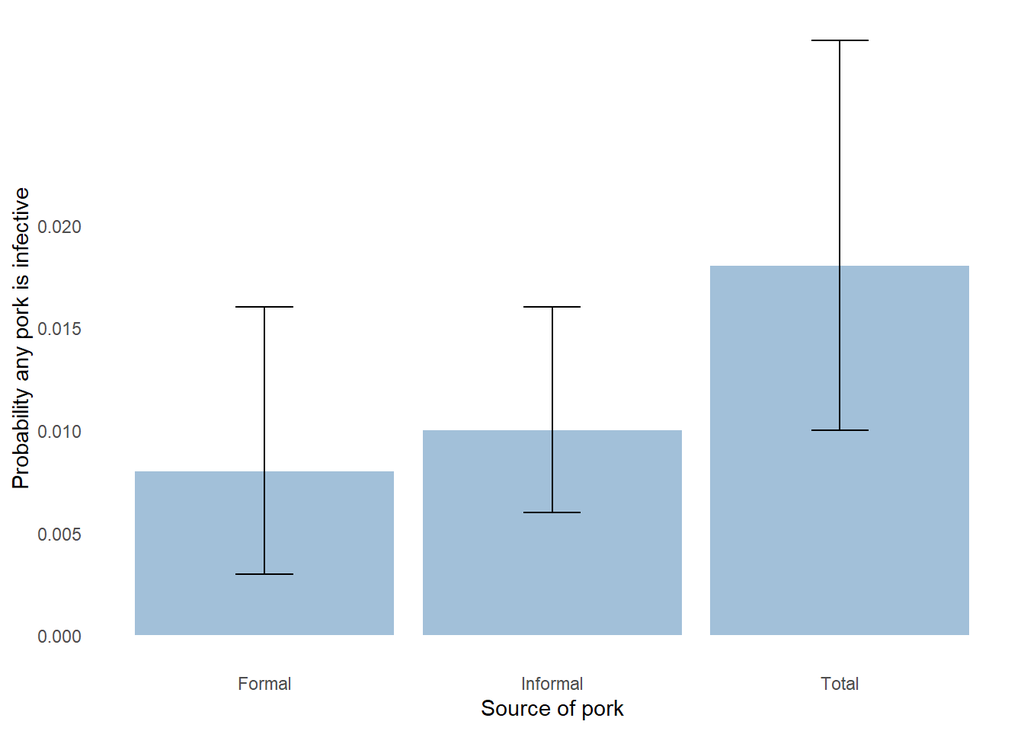

```r
library(ggplot2)
# Parameters for A=formal, B=Informal, and C= Total
A_mean <- 0.008
A_lower <- 0.003
A_upper <- 0.016
B_mean <- 0.010
B_lower <- 0.006
B_upper <- 0.016
C_mean <- 0.018
C_lower <- 0.010
C_upper <- 0.029

### means and uncertainty intervals
means_data <- data.frame(
  group = c("Formal", "Informal", "Total"),
  mean = c(A_mean, B_mean, C_mean),
  lower = c(A_lower, B_lower, C_lower),
  upper = c(A_upper, B_upper, C_upper)
)

#### A bar plot with uncertainty intervals
ggplot(means_data, aes(x = group, y = mean, fill = group)) +
  geom_bar(stat = "identity", alpha = 0.5, position = position_dodge()) +
  geom_errorbar(aes(ymin = lower, ymax = upper), width = 0.2, color = "black", position = position_dodge(0.7)) +
  labs(
       x = "Source of pork",
       y = "Probability any pork is infective") +
  scale_fill_manual(values = c("steelblue", "steelblue", "steelblue")) +scale_y_continuous(breaks = seq(0, 0.02, by = 0.005))+
  theme_minimal() +
  theme(panel.grid = element_blank(), legend.position = "none")
```

### BAR PLOT-INFECTIVE MEALS

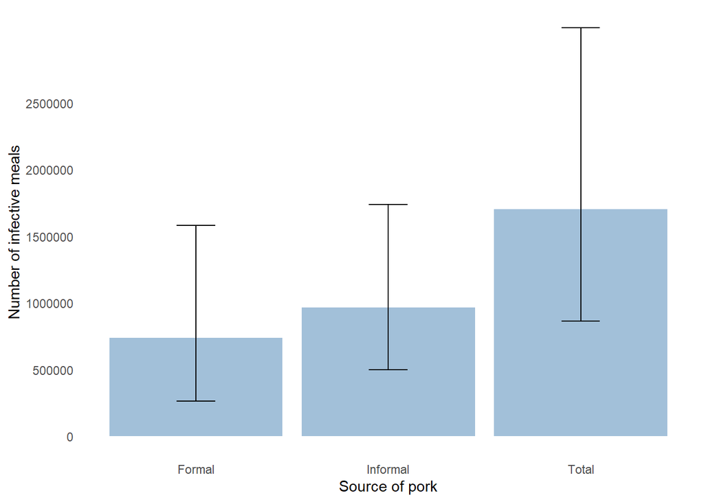

```r
library(ggplot2)

# Parameters for A=formal, B=Informal, and C= Total
A_mean <- 736956
A_lower <- 263097
A_upper <- 1582614
B_mean <- 964371
B_lower <- 497691
B_upper <- 1739119
C_mean <-  1701327
C_lower <- 864720
C_upper <- 3062707

### means and uncertainty intervals
means_data <- data.frame(
  group = c("Formal", "Informal", "Total"),
  mean = c(A_mean, B_mean, C_mean),
  lower = c(A_lower, B_lower, C_lower),
  upper = c(A_upper, B_upper, C_upper)
)

#### A bar plot with uncertainty intervals
ggplot(means_data, aes(x = group, y = mean, fill = group)) +
  geom_bar(stat = "identity", alpha = 0.5, position = position_dodge()) +
  geom_errorbar(aes(ymin = lower, ymax = upper), width = 0.2, color = "black", position = position_dodge(0.7)) +
  labs(
    x = "Source of pork",
    y = "Number of infective meals") +
  scale_fill_manual(values = c("steelblue", "steelblue", "steelblue")) +scale_y_continuous(breaks = seq(0,2500000, by =500000))+
  theme_minimal() +
  theme(panel.grid = element_blank(), legend.position = "none")
```

### BAR PLOT - Frequency of pork consumption per year

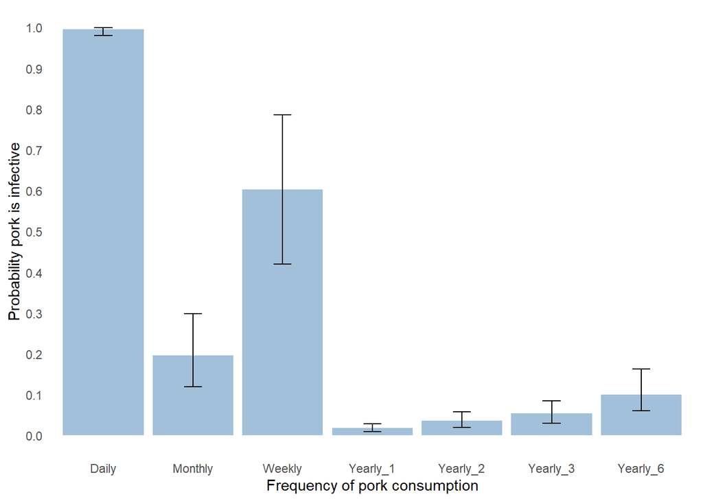

```r
library(ggplot2)
# Parameters for A= Daily, B=Weekly, and C= Monthly, D = Yearly_1, E=Yearly_2,
# F= Yearly_3, G= Yearly_6

A_mean <- 0.996
A_lower <- 0.98
A_upper <- 0.999
B_mean <- 0.603
B_lower <- 0.42
B_upper <- 0.786
C_mean <- 0.196
C_lower <- 0.12
C_upper <- 0.299
D_mean <- 0.018
D_lower <- 0.01
D_upper <- 0.029
E_mean <- 0.036
E_lower <- 0.02
E_upper <- 0.058
F_mean <- 0.054
F_lower <- 0.03
F_upper <- 0.085
G_mean <- 0.10
G_lower <- 0.06
G_upper <- 0.163

### means and uncertainty intervals
means_data <- data.frame(
  group = c("Daily", "Weekly", "Monthly", "Yearly_1","Yearly_2", "Yearly_3", "Yearly_6"),
  mean = c(A_mean, B_mean, C_mean, D_mean,E_mean, F_mean, G_mean ),
  lower = c(A_lower, B_lower, C_lower, D_lower, E_lower, F_lower, G_lower),
  upper = c(A_upper, B_upper, C_upper, D_upper, E_upper, F_upper, G_upper)
)

#### A bar plot with uncertainty intervals
ggplot(means_data, aes(x = group, y = mean, fill = group)) +
  geom_bar(stat = "identity", alpha = 0.5, position = position_dodge()) +
  geom_errorbar(aes(ymin = lower, ymax = upper), width = 0.2, color = "black", position = position_dodge(0.7)) +
  labs(
    x = "Frequency of pork consumption",
    y = "Probability pork is infective") +
  scale_fill_manual(values = c("steelblue", "steelblue", "steelblue","steelblue", "steelblue", "steelblue", "steelblue" )) +scale_y_continuous(breaks = seq(0,1, by =0.1))+
  theme_minimal() +
  theme(panel.grid = element_blank(), legend.position = "none")
```

### Number of meals based on location, slaughter, pig system after cooking

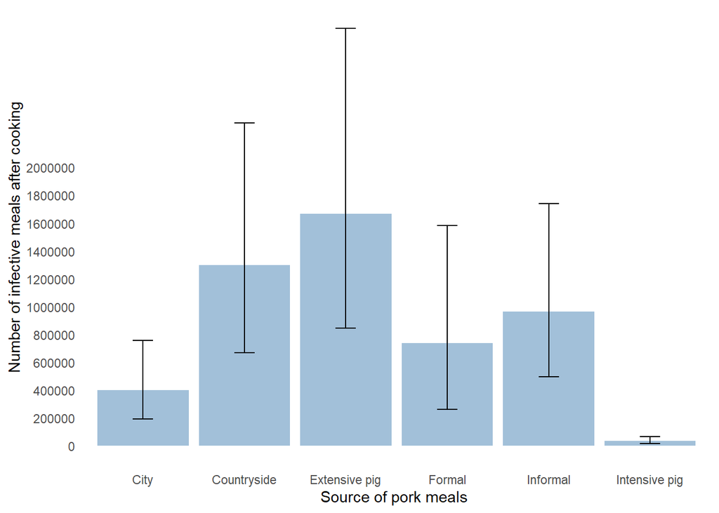

```r
library(ggplot2)
# Parameters for A= Countryside, B= City, and C= Extensive, D = Intensive, E= Formal,
# F= Informal

A_mean <- 1298783
A_lower <- 669848
A_upper <- 2319713
B_mean <- 402544
B_lower <- 191630
B_upper <- 756661
C_mean <- 1665624
C_lower <- 846151
C_upper <- 2998891
D_mean <-  35703
D_lower <- 17410
D_upper <- 65685
E_mean <- 736956
E_lower <- 263097
E_upper <- 1582614
F_mean <- 964371
F_lower <- 497691
F_upper <- 1739119

### means and uncertainty intervals
means_data <- data.frame(
  group = c("Countryside", "City", "Extensive pig", "Intensive pig","Formal", "Informal"),
  mean = c(A_mean, B_mean, C_mean, D_mean,E_mean, F_mean),
  lower = c(A_lower, B_lower, C_lower, D_lower, E_lower, F_lower),
  upper = c(A_upper, B_upper, C_upper, D_upper, E_upper, F_upper))

#### A bar plot with uncertainty intervals
ggplot(means_data, aes(x = group, y = mean, fill = group)) +
  geom_bar(stat = "identity", alpha = 0.5, position = position_dodge()) +
  geom_errorbar(aes(ymin = lower, ymax = upper), width = 0.2, color = "black", position = position_dodge(0.7)) +
  labs(
    x = "Source of pork meals ",
    y = "Number of infective meals after cooking") +
  scale_fill_manual(values = c("steelblue", "steelblue", "steelblue","steelblue", "steelblue", "steelblue" )) +scale_y_continuous(breaks = seq(0,2000000, by =200000))+
  theme_minimal() +
  theme(panel.grid = element_blank(), legend.position = "none")
```

### Number of meals based on location, slaughter, pig system before cooking

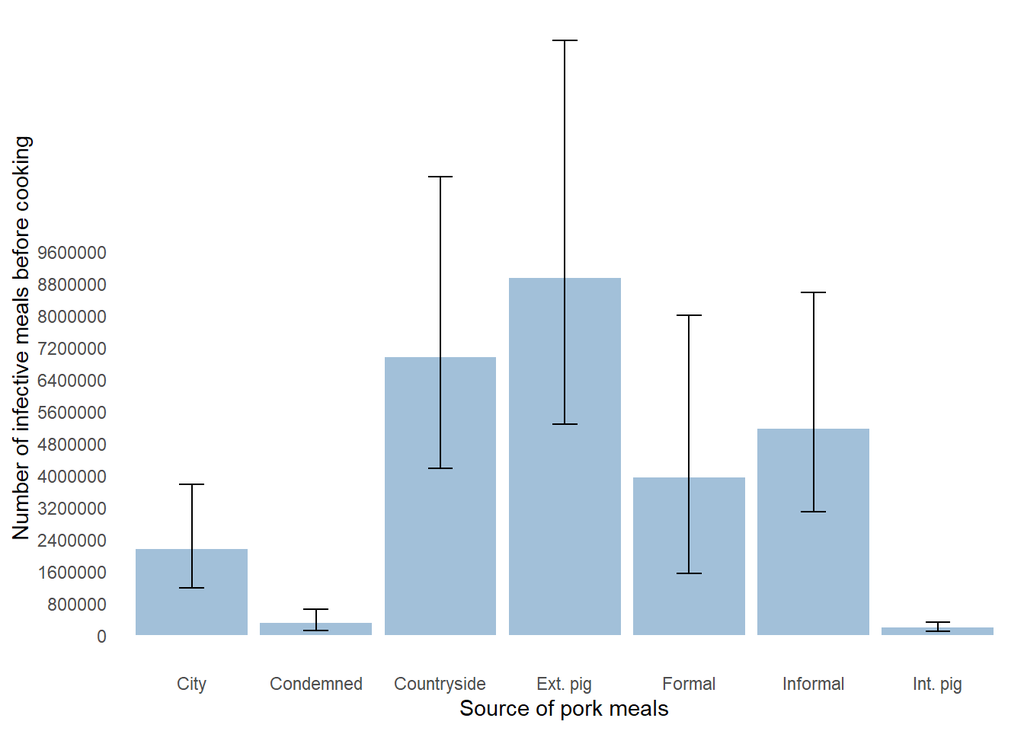

```r
library(ggplot2)
# Parameters for A= Countryside, B= City, and C= Extensive, D = Intensive, E= Formal,
# F= Informal, G= Condemned

A_mean <- 6964318
A_lower <- 4184130
A_upper <- 11464638
B_mean <- 2158580
B_lower <- 1179805
B_upper <- 3784519
C_mean <- 8931456
C_lower <- 5280898
C_upper <- 14870480
D_mean <- 191442
D_lower <- 106473
D_upper <- 325402
E_mean <- 3951971
E_lower <- 1550310
E_upper <- 8007697
F_mean <- 5170927
F_lower <- 3091039
F_upper <- 8572059
G_mean <-  311820
G_lower <- 117775
G_upper <- 661994

### means and uncertainty intervals
means_data <- data.frame(
  group = c("Countryside", "City", "Ext. pig", "Int. pig","Formal", "Informal", "Condemned"),
  mean = c(A_mean, B_mean, C_mean, D_mean,E_mean, F_mean, G_mean),
  lower = c(A_lower, B_lower, C_lower, D_lower, E_lower, F_lower, G_lower),
  upper = c(A_upper, B_upper, C_upper, D_upper, E_upper, F_upper, G_upper))

#### A bar plot with uncertainty intervals
ggplot(means_data, aes(x = group, y = mean, fill = group)) +
  geom_bar(stat = "identity", alpha = 0.5, position = position_dodge()) +
  geom_errorbar(aes(ymin = lower, ymax = upper), width = 0.2, color = "black", position = position_dodge(0.7)) +
  labs(
    x = "Source of pork meals",
    y = "Number of infective meals before cooking") +
  scale_fill_manual(values = c("steelblue", "steelblue", "steelblue","steelblue", "steelblue", "steelblue", "steelblue", "steelblue" )) +scale_y_continuous(breaks = seq(0,10000000, by =800000))+
  theme_minimal() +
  theme(panel.grid = element_blank(), legend.position = "none")
```

### Probability infective based on intensity of infection

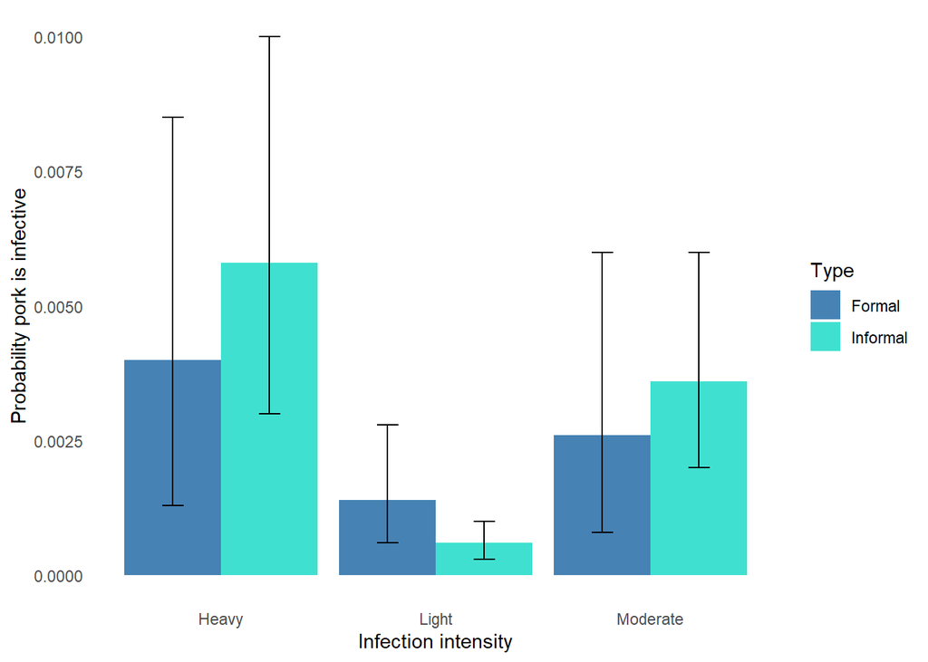

```r
library(ggplot2)
# Create the dataset with probabilities and ranges
Infective_data <- data.frame(
  Intensity = c("Light", "Moderate", "Heavy"),
  Prob_Formal = c(0.0014, 0.0026, 0.004),
  CI_Formal_Lower = c(0.0006, 0.0008, 0.0013),
  CI_Formal_Upper = c(0.0028, 0.006, 0.0085),
  Prob_informal = c(0.0006, 0.0036, 0.0058),
  CI_Informal_Lower = c(0.0003, 0.002, 0.003),
  CI_Informal_Upper = c(0.001, 0.006, 0.010)
)

# Convert data to long format for easy ggplot handling
library(reshape2)
Infective_data_long <- melt(Infective_data, id.vars = "Intensity")

# Subset data for Formal and Informal separately
Formal_data <- Infective_data[, c("Intensity", "Prob_Formal", "CI_Formal_Lower", "CI_Formal_Upper")]
Formal_data$Type <- "Formal"
names(Formal_data) <- c("Intensity", "Probability", "CI_Lower", "CI_Upper", "Type")

Informal_data <- Infective_data[, c("Intensity", "Prob_informal", "CI_Informal_Lower", "CI_Informal_Upper")]
Informal_data$Type <- "Informal"
names(Informal_data) <- c("Intensity", "Probability", "CI_Lower", "CI_Upper", "Type")

# Combine the data
plot_data <- rbind(Formal_data, Informal_data)

# Create the bar plot with error bars
ggplot(plot_data, aes(x = Intensity, y = Probability, fill = Type)) +
  geom_bar(stat = "identity", position = "dodge") +
  geom_errorbar(aes(ymin = CI_Lower, ymax = CI_Upper),
                width = 0.2, position = position_dodge(0.9)) +
  labs(
       x = "Infection intensity",
       y = "Probability pork is infective",
       fill = "Type") +scale_fill_manual(values = c("Formal" = "steelblue", "Informal" = "turquoise"))+
  theme_minimal()+theme(panel.grid = element_blank())
```

### SENSITIVITY ANALYSES

### SENSITIVITY ANALYSIS FUNCTIONS

```r
## standardized regression coefficients
sa_src <-
function(y, x) {
  df <- as.data.frame(apply(x, 2, scale))
  summary(lm(scale(y) ~ ., data = df))
}
```

## partial correlation coefficients

```r
## partial correlation coefficients
sa_pcc <-
function(y, x) {
  out <- matrix(ncol = 2, nrow = ncol(x))
  colnames(out) <- c("rho", "p")
  rownames(out) <- colnames(x)

  for (i in seq(ncol(x))){
    lm_y <- lm(y ~ x[, -i])      # regress y to other x's
    lm_x <- lm(x[, i] ~ x[, -i]) # regress x to other x's
    out[i, ] <-
      unlist(cor.test(lm_y$residuals, lm_x$residuals)[4:3],
             use.names = FALSE)
  }

  return(out[order(abs(out[, "rho"]), decreasing = TRUE), ])
}
```

### TORNADO GRAPH

```r
###
library(ggplot2)

## ggplot2
tornado <-
function(coef, names = NULL) {
  ## copy names if needed
  if (is.null(names)) names <- rownames(coef)

  ## create data frame
  df <- data.frame(est = coef[, "rho"],
                   order = order(abs(coef[, "rho"])),
                   name = names)

  ## sort data frame
  df <- df[df$order, ]

  ## create ggplot
  ggplot(df, aes(x = order, y = est)) +
    geom_bar(stat = "identity") +
    coord_flip() +
    scale_x_continuous(element_blank(),
                       breaks = seq(nrow(df)),
                       labels = df$name) +
    scale_y_continuous("Partial correlation coefficient",
                       limits = c(min(0, min(df$est) - 0.1),
                                  max(0, max(df$est) + 0.1))) +
    geom_text(aes(x = order, y = est, label = formatC(est, 3, form = "f")),
              size = 3,
              hjust = ifelse(df$est > 0, -0.1, 1.1),
              vjust = 0.4) +
    theme_bw()
}
```

### Load QMRA TS script

### RISK AFTER COOKING

```r
## RISK AFTER COOKING
sa_src(Tot_prob_infective_AC,
       cbind(Prev_MI, Prev_Tp, Prev_ext_MI, Prev_ext_pig, Prev_int_pig, Heavy_Inf, Moderate_Inf, Light_Inf, Heavy_inform, Moder_inform, Pmeal1, Pmeal2, Pmeal3, Viable_cyst, undercooked, meal_pig))
```

```
##
## Call:
## lm(formula = scale(y) ~ ., data = df)
##
## Residuals:
##      Min       1Q   Median       3Q      Max
## -1.09116 -0.08109 -0.01094  0.06618  2.30674
##
## Coefficients:
##                Estimate Std. Error  t value Pr(>|t|)
## (Intercept)  -8.061e-15  5.197e-04    0.000   1.0000
## Prev_MI      -3.676e-04  5.197e-04   -0.707   0.4793
## Prev_Tp      -2.981e-04  5.197e-04   -0.574   0.5662
## Prev_ext_MI   5.331e-01  5.197e-04 1025.802   <2e-16 ***
## Prev_ext_pig  2.414e-01  5.197e-04  464.515   <2e-16 ***
## Prev_int_pig  9.644e-03  5.197e-04   18.557   <2e-16 ***
## Heavy_Inf     2.114e-01  5.197e-04  406.668   <2e-16 ***
## Moderate_Inf  1.650e-01  5.197e-04  317.517   <2e-16 ***
## Light_Inf     2.353e-02  5.197e-04   45.273   <2e-16 ***
## Heavy_inform  2.414e-01  5.197e-04  464.540   <2e-16 ***
## Moder_inform  1.040e-01  5.197e-04  200.051   <2e-16 ***
## Pmeal1        8.045e-02  2.931e-03   27.446   <2e-16 ***
## Pmeal2        2.523e-02  3.035e-02    0.831   0.4059
## Pmeal3       -2.865e-03  1.398e-03   -2.049   0.0405 *
## Viable_cyst   1.803e-02  5.197e-04   34.698   <2e-16 ***
## undercooked   6.745e-01  5.197e-04 1297.971   <2e-16 ***
## meal_pig     -7.489e-02  3.270e-02   -2.290   0.0220 *
## ---
## Signif. codes:  0 '***' 0.001 '**' 0.01 '*' 0.05 '.' 0.1 ' ' 1
##
## Residual standard error: 0.1643 on 99983 degrees of freedom
## Multiple R-squared:  0.973,  Adjusted R-squared:  0.973
## F-statistic: 2.252e+05 on 16 and 99983 DF,  p-value: < 2.2e-16
```

```r
sa_Risk_AC_pcc <-
  sa_pcc(Tot_prob_infective_AC,
         cbind(Prev_MI, Prev_Tp, Prev_ext_MI, Prev_ext_pig, Prev_int_pig, Heavy_Inf, Moderate_Inf, Light_Inf, Heavy_inform, Moder_inform, Pmeal1, Pmeal2, Pmeal3, Viable_cyst, undercooked, meal_pig))

sa_Risk_AC_pcc
```

```
##                       rho             p
## undercooked   0.971585334  0.000000e+00
## Prev_ext_MI   0.955629753  0.000000e+00
## Heavy_inform  0.826666998  0.000000e+00
## Prev_ext_pig  0.826652936  0.000000e+00
## Heavy_Inf     0.789442677  0.000000e+00
## Moderate_Inf  0.708573921  0.000000e+00
## Moder_inform  0.534651445  0.000000e+00
## Light_Inf     0.141732608  0.000000e+00
## Viable_cyst   0.109080706 2.784557e-262
## Pmeal1        0.086474858 2.999178e-165
## Prev_int_pig  0.058587541  9.340600e-77
## meal_pig     -0.007242404  2.200679e-02
## Pmeal3       -0.006478607  4.049034e-02
## Pmeal2        0.002628669  4.058329e-01
## Prev_MI      -0.002237139  4.792947e-01
## Prev_Tp      -0.001814375  5.661377e-01
```

```r
## tornado graph
Risk_AC_items <-
  c( "Prop. undercooked pork", "Prev. meat inspection extensive pig","Prop. heavy infection informal", "Prev. tongue palpation extensive farm", "Prop. heavy infection formal", "Prop. moderate infection formal", "Prop. moderate infection informal", "Prop. light infection formal", "Prob. viable cyst", "Prob. meal light infection","Prev. tongue palpation intensive farm", "Meals per pig", "Prob. meal heavy infection", "Prob. meal moderate infection", "Overall prev. meat inspection", "Overall prev. tongue palpation in pig")

png("sa_Risk_AC_pcc.png",  7, 3.5, units = "in", res = 400)
tornado(sa_Risk_AC_pcc, Risk_AC_items)
graphics.off()
```